# 05_rq3_expansion_priorities_v2

### Estrutura notebook 05

Adequação territorial e análise espacial

Estrutura 5.1 Introdução 5.2 Preparação dos dados 5.3 Análise exploratória espacial 5.4 Moran's I 5.5 LISA 5.6 Identificação de áreas prioritárias 5.7 Caracterização funcional dos postos 5.8 Cruzamento com tipologias 5.9 Contexto territorial 5.9.1–5.9.4 Municípios 5.9.5 Facilities, Parking e Rede Viária 5.9.6 Caso de estudo: Distrito de Coimbra 5.10 Síntese da RQ3

-- 05_rq3_expansion_priorities.ipynb -- Análise: procura potencial cobertura défice de oferta suitability

INPUTS: INE CAOP COS rede viária v20_oferta_posto v50_pressao_posto

OUTPUTS: mapas de cobertura postos por habitante postos por km de via áreas prioritárias

5.1 Setup and database connection  
5.2 Integrated data preparation  
5.3 Exploratory spatial analysis  
5.4 Global Moran's I  
5.5 Local Moran's I (LISA)  
5.6 Identification of priority stations  
5.7 Functional characterisation of priority stations  
5.8 Relationship between K-Means typologies and LISA patterns  
5.9 Territorial context: population, charging supply and road coverage  
5.10 Sensitivity analysis excluding Lisbon and Porto  
5.11 Case study: District of Coimbra  
5.12 RQ3 synthesis  
5.13 Export of results

### 5.1 SETUP e Ligação à BD

```python
# ---------------------------------------
#           Setup e ligação à DB
# ---------------------------------------
import sys
import os

import pandas as pd
import geopandas as gpd
import numpy as np

import geopandas as gpd
from shapely import wkb, wkt
from shapely.geometry.base import BaseGeometry

from sqlalchemy import create_engine
from pathlib import Path

import matplotlib.pyplot as plt

# adicionar o caminho - sobe um nível
#sys.path.append(os.path.abspath(".."))
#print(os.getcwd())

# encontrar o caminho para a raiz do projeto (/projeto)
projeto_path = os.path.abspath(os.path.join(os.getcwd(), ".."))

# adicionar o novo caminho ao sys.path, caso ainda não esteja
if(projeto_path not in sys.path):
    sys.path.append(projeto_path)

# adicionar a pasta "projeto" ao sys.path
from db.config import DB_CONFIG
from sqlalchemy import create_engine

# funções para desenhar mapa por distrito com labels e contornos
#from libs.map_utils import get_limites_distrito, plot_postos_distrito
import importlib
import libs.map_utils as munic
#importlib.reload(libs.map_utils)
importlib.reload(munic)

FIG_DIR = Path("../outputs/figures")
FIG_DIR.mkdir(parents=True, exist_ok=True)

TABLE_DIR = Path("../outputs/tables")
TABLE_DIR.mkdir(parents=True, exist_ok=True)

# função para criar a engine à bd remota
def get_engine():
    return create_engine(
        f"postgresql+psycopg2://{DB_CONFIG['user']}:{DB_CONFIG['password']}@"
        f"{DB_CONFIG['host']}:{DB_CONFIG['port']}/{DB_CONFIG['dbname']}"
    )

# cria a engine
engine = get_engine()
#print(engine)
```

```python
# ---------------------------------------------------
# Criação do ambiente para a análise
# ---------------------------------------------------
"""
    - variáveis para analisar:
        -- por distrito
        -- gráfico - dimensão
        -- labels do gráfico
"""
# distrito
DISTRITO = "Coimbra"
EXCLUDES = ["Lisboa", "Porto"]

# plot dos gráfics
FIGSIZE = (10, 10)
SHOW_LABELS = True

# variáveis para o mapa
VARIAVEIS_MAPA = [
    "x"
]

K_NEIGHBORS = 13
ALPHA_LISA = 0.05

CLUSTERS_FILE = "../outputs/clusters_kmeans_k4_final.csv"
RQ3_OUTPUT_FILE = "../outputs/rq3_context.csv"
```

```python
# ---------------------------------------
# Funções auxiliares
# ---------------------------------------

def read_sql(query):
    return pd.read_sql(query, engine)

def read_gdf(query, geom_col="geom"):
    return gpd.read_postgis(query, engine, geom_col=geom_col)

def anonymise_station_labels(df, id_col="id_charging_station", label_col="station_label"):
    """
        Creates anonymised station labels for sensivel data
    """
    df_out = df.copy()

    df_out[label_col] = [
        f"CS{i:03d}"
        for i in range(1, len(df_out) + 1)
    ]

    return df_out
```

```python
import geopandas as gpd

import libpysal
import esda

from libpysal.weights import KNN

from esda.moran import Moran
from esda.moran import Moran_Local

print("Bibliotecas OK")
```

```
Bibliotecas OK
```

### 5.2 Preparação dos dados

```python
# ------------------------------------------------------------------------------------------------------
# Carregar os dados espaciais :: com a geometria
# input: v51_pressao_posto_spatia (v20_oferta_posto; v50_pressao_posto)
# ------------------------------------------------------------------------------------------------------

query = "SELECT * FROM v51_pressao_posto_spatial"
gdf = read_gdf(
    query,
    geom_col="geom"
)


print(f"Dimensão inicial: {gdf.shape}")
print(f"CRS: {gdf.crs}")
print(f"Geometrias nulas: {gdf.geometry.isna().sum()}")
print(
    f"Postos únicos: "
    f"{gdf['id_charging_station'].nunique()}")
```

```
Dimensão inicial: (9309, 31)
CRS: EPSG:3763
Geometrias nulas: 0
Postos únicos: 9309
```

```python
print(gdf.geometry.name)
```

```
geom
```

```python
clusters_kmeans = pd.read_csv(
    "../outputs/clusters_kmeans_k4_final.csv"
)

gdf = (
    gdf
    .drop(columns=["cluster"], errors="ignore")
    .merge(
        clusters_kmeans,
        on="id_charging_station",
        how="left",
        validate="one_to_one"
    )
)

display(
    gdf["cluster"]
    .value_counts(dropna=False)
    .sort_index()
)

# print(gdf["cluster"].value_counts(dropna=False).sort_index())
```

```
cluster
0    3636
1    2598
2    1195
3    1880
Name: count, dtype: int64
```

```python
cols_descritivas = [
    "sessoes_mes_ativo",
    "kwh_mes_ativo",
    "sessoes_por_evse_instalado",
    "sessoes_por_conector_instalado",
    "kwh_por_kw_instalado",
    "n_evse_instalados",
    "n_conectores_instalados",
    "potencia_total_kw",
    "potencia_max_kw",
    "pct_fim_semana",
    "pct_horario_laboral",
    "pct_periodo_descanso",
    "pct_feriado"
]

display(
    gdf[cols_descritivas]
    .describe()
    .round(2)
)
```

|  | sessoes_mes_ativo | kwh_mes_ativo | sessoes_por_evse_instalado | sessoes_por_conector_instalado | kwh_por_kw_instalado | n_evse_instalados | n_conectores_instalados | potencia_total_kw | potencia_max_kw | pct_fim_semana | pct_horario_laboral | pct_periodo_descanso | pct_feriado |
| --- | --- | --- | --- | --- | --- | --- | --- | --- | --- | --- | --- | --- | --- |
| count | 9309.00 | 9309.00 | 9309.00 | 9309.00 | 9309.00 | 9309.00 | 9309.00 | 9309.00 | 9309.00 | 9309.00 | 9309.00 | 9309.00 | 9309.00 |
| mean | 60.64 | 1293.22 | 391.23 | 382.64 | 265.33 | 2.13 | 2.16 | 109.52 | 35.25 | 0.25 | 0.42 | 0.32 | 0.03 |
| std | 96.06 | 2533.11 | 576.89 | 555.44 | 489.30 | 1.17 | 1.18 | 227.96 | 44.89 | 0.14 | 0.18 | 0.22 | 0.04 |
| min | 1.00 | 0.10 | 0.25 | 0.25 | 0.00 | 1.00 | 1.00 | 2.30 | 2.30 | 0.00 | 0.00 | 0.00 | 0.00 |
| 25% | 8.55 | 148.22 | 48.00 | 47.00 | 38.56 | 1.00 | 1.00 | 22.00 | 11.00 | 0.19 | 0.33 | 0.18 | 0.01 |
| 50% | 22.24 | 413.61 | 161.00 | 161.00 | 125.29 | 2.00 | 2.00 | 44.00 | 22.00 | 0.28 | 0.41 | 0.30 | 0.03 |
| 75% | 75.48 | 1467.19 | 477.00 | 475.00 | 306.03 | 3.00 | 3.00 | 122.00 | 50.00 | 0.33 | 0.49 | 0.41 | 0.04 |
| max | 2556.25 | 91889.88 | 5112.50 | 5112.50 | 8098.98 | 12.00 | 12.00 | 7000.00 | 400.00 | 1.00 | 1.00 | 1.00 | 1.00 |

```python
# --------------------------------------------------
# Variáveis utilizadas na análise espacial da RQ3
# --------------------------------------------------

rq3_numeric_features = [
    # Procura observada
    "sessoes_mes_ativo",
    "kwh_mes_ativo",

    # Pressão relativa à infraestrutura instalada
    "sessoes_por_evse_instalado",
    "sessoes_por_conector_instalado",

    # Intensidade da energia instalada
    "kwh_por_kw_instalado",

    # Oferta instalada
    "n_evse_instalados",
    "n_conectores_instalados",
    "potencia_total_kw",
    "potencia_max_kw",

    # Tecnologia
    "tem_dc",
    "tem_rapido",

    # Padrões temporais
    "pct_fim_semana",
    "pct_horario_laboral",
    "pct_periodo_descanso",
    "pct_feriado"
]

rq3_categorical_features = [
    "classe_pressao_observada"
]

rq3_features = (
    rq3_numeric_features
    + rq3_categorical_features
)

# Indicadores principais para cartografia e Moran's I
spatial_vars = [
    "sessoes_mes_ativo",
    "sessoes_por_evse_instalado",
    "kwh_por_kw_instalado"
]

MORAN_VARS = spatial_vars
LISA_VAR = "sessoes_por_evse_instalado"
```

```python
# --------------------------------------------------
# DataFrame definitivo para a análise espacial
# --------------------------------------------------

gdf_rq3 = (
    gdf
    .dropna(
        subset=rq3_features + ["cluster"]
    )
    .copy()
)

gdf_rq3 = gdf_rq3[
    gdf_rq3.geometry.notna()
].copy()

print(f"Dimensão inicial: {gdf.shape}")
print(f"Dimensão após validação: {gdf_rq3.shape}")
print(f"Postos removidos: {len(gdf) - len(gdf_rq3)}")
```

```
Dimensão inicial: (9309, 32)
Dimensão após validação: (9309, 32)
Postos removidos: 0
```

```python
# ------------------------------------------------------------------------------------------------------
# Consolidar os postos (validar que após juntar os clusters, continuam a existir os 9309)
# ------------------------------------------------------------------------------------------------------
gdf = gdf_rq3.copy()

assert len(gdf) == 9309
assert gdf["id_charging_station"].is_unique
assert gdf.geometry.notna().all()
assert gdf["cluster"].notna().all()

print("GeoDataFrame definitivo da RQ3 validado.")
```

```
GeoDataFrame definitivo da RQ3 validado.
```

```python
# ---------------------------------------------------
# Validação da classe de pressão
# ---------------------------------------------------

display(
    gdf["classe_pressao_observada"]
    .value_counts(dropna=False)
    .rename_axis("classe_pressao_observada")
    .reset_index(name="n_postos")
)
```

|  | classe_pressao_observada | n_postos |
| --- | --- | --- |
| 0 | Baixa | 6190 |
| 1 | Média | 2442 |
| 2 | Alta | 626 |
| 3 | Muito Alta | 51 |

The definitive spatial-analysis GeoDataFrame is created and validated in the preceding cells. No additional filtering is required here.

```python
# ---------------------------------------------------
# Features (RQ3)
# ---------------------------------------------------
rq3_features = [
    # Procura absoluta
    "sessoes_mes_ativo",
    "kwh_mes_ativo",

    # Pressão relativa da infraestrutura
    "sessoes_por_evse_instalado",
    "sessoes_por_conector_instalado",

    # Eficiência / intensidade energética
    "kwh_por_kw_instalado",

    # Oferta instalada
    "n_evse_instalados",
    "n_conectores_instalados",
    "potencia_total_kw",
    "potencia_max_kw",

    # Tipo de infraestrutura
    "tem_dc",
    "tem_rapido"
]
```

# 5.3 Análise exploratória espacial

```python
# ----------------------------------------------------------------------------
# Query auxiliar para os mapas com distrito (linha divisória dos distritos)
# ----------------------------------------------------------------------------
query_caop = """
    SELECT
        distrito,
        municipio,
        geom
    FROM v00_caop_municipios
    WHERE nuts_1 = 'Continente'
"""

gdf_municipios = read_gdf(
    query_caop,
    geom_col="geom"
).to_crs(epsg=3763)

print(gdf_municipios.shape)
print(gdf_municipios.crs)
```

```
(278, 3)
EPSG:3763
```

### 5.3.1 Mapa de procura observada

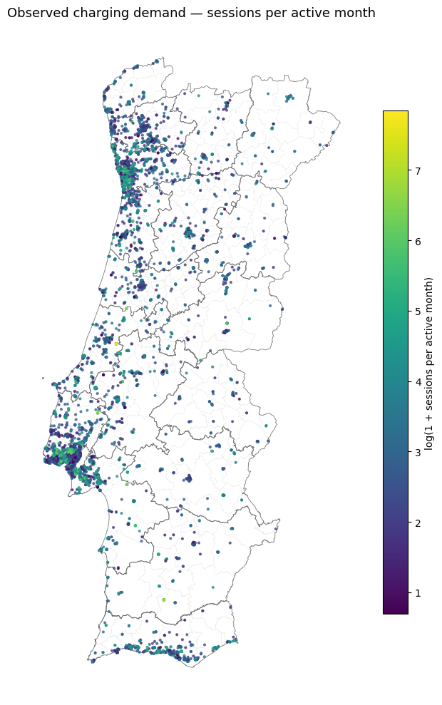

```python
fig, ax = munic.plot_continuous_with_boundaries(
    gdf_points=gdf,
        gdf_municipios=gdf_municipios,
        column="sessoes_mes_ativo",
        title="Observed charging demand — sessions per active month",
        legend_label="log(1 + sessions per active month)",
        outfile="rq3_observed_demand_sessions_month_1.png",
        use_log=True,
        markersize=4
)
```

### 5.3.2 Mapa de pressão por EVSE

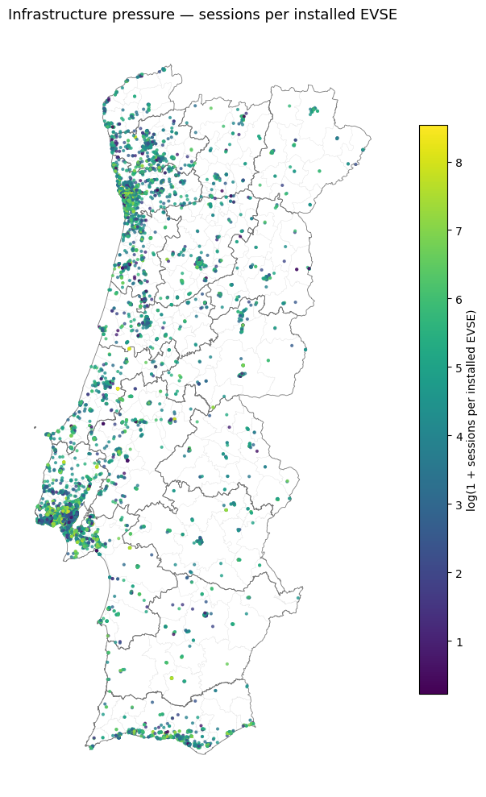

```python
fig, ax = munic.plot_continuous_with_boundaries(
    gdf_points=gdf,
    gdf_municipios=gdf_municipios,
    column="sessoes_por_evse_instalado",
    title="Infrastructure pressure — sessions per installed EVSE",
    legend_label="log(1 + sessions per installed EVSE)",
    outfile="rq3_pressure_sessions_per_evse.png",
    use_log=True,
    markersize=4
)
```

### 5.3.3 Mapa de kWh por kW instalado

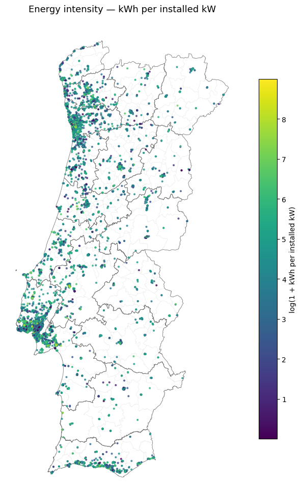

```python
fig, ax = munic.plot_continuous_with_boundaries(
    gdf_points=gdf,
    gdf_municipios=gdf_municipios,
    column="kwh_por_kw_instalado",
    title="Energy intensity — kWh per installed kW",
    legend_label="log(1 + kWh per installed kW)",
    outfile="rq3_energy_intensity_kwh_per_kw.png",
    use_log=True,
    markersize=4
)
```

# 5.4 Moran's I

```python
# ---------------------------------------------------
# obter os x (15) vizinhos mais próximos
# ---------------------------------------------------

"""
        Com K=8 apresenta 21 desconectados
        com k=12 apresenta 2 desconectados
        com k=15 ok
"""
from libpysal.weights import KNN

w = KNN.from_dataframe(
    gdf,
    k=13
)

#print(w.n_components)
w.transform = "R"

#np.bincount(w.component_labels)

print(f"Number of observations: {w.n:,}")
print(f"Number of neighbours: {K_NEIGHBORS}")
print(f"Connected components: {w.n_components}")
print(f"Islands: {len(w.islands)}")

assert w.n == len(gdf)
assert w.n_components == 1
assert len(w.islands) == 0

print("Spatial weights matrix successfully validated.")
```

```
Number of observations: 9,309
Number of neighbours: 13
Connected components: 1
Islands: 0
Spatial weights matrix successfully validated.
```

```python
# -------------------------------------------------------------------------------------------------------------------------------
# Global Moran's I
#       - Procura observada de pontos de carregamento (sessoes_mes_ativo)
#       - Pressão relativa sobre as infraestruturassobre - pontos de carregamento (sessoes_por_evse_instalado)
#       - intensidade energética sobre os pontos de carregamento (kwh_por_kw_instalado)
# -------------------------------------------------------------------------------------------------------------------------------

from esda.moran import Moran

moran_results = []
moran_objects = {}

for variable in MORAN_VARS:
    values = gdf[variable].to_numpy()

    moran = Moran(
        values,
        w,
        permutations=999
    )

    # Guardar o objeto para o caso de ser necessário posteriormente
    moran_objects[variable] = moran

    moran_results.append({
        "variable": variable,
        "moran_i": moran.I,
        "expected_i": moran.EI,
        "z_sim": moran.z_sim,
        "p_sim": moran.p_sim
    })

moran_results_df = pd.DataFrame(moran_results)

#display(moran_results_df.round(4))

#print(moran_objects["sessoes_por_evse_instalado"].I)
```

```python
MORAN_LABELS = {
    "sessoes_mes_ativo":
        "Sessions per active month",

    "sessoes_por_evse_instalado":
        "Sessions per installed EVSE",

    "kwh_por_kw_instalado":
        "Energy per installed kW"
}

moran_results_report = (
    moran_results_df
    .assign(indicator=lambda df: df["variable"].map(MORAN_LABELS))
    [
        [
            "indicator",
            "moran_i",
            "expected_i",
            "z_sim",
            "p_sim"
        ]
    ]
)

#display(moran_results_report.round(4))

def interpret_moran(moran_i, p_value):
    if p_value >= 0.05:
        return "Not statistically significant"

    if moran_i > 0:
        return "Positive spatial autocorrelation"

    if moran_i < 0:
        return "Negative spatial autocorrelation"

    return "No spatial autocorrelation"


moran_results_report["interpretation"] = (
    moran_results_report.apply(
        lambda row: interpret_moran(
            row["moran_i"],
            row["p_sim"]
        ),
        axis=1
    )
)

display(
    moran_results_report.round(4)
)
```

|  | indicator | moran_i | expected_i | z_sim | p_sim | interpretation |
| --- | --- | --- | --- | --- | --- | --- |
| 0 | Sessions per active month | 0.1697 | -0.0001 | 45.6243 | 0.001 | Positive spatial autocorrelation |
| 1 | Sessions per installed EVSE | 0.1940 | -0.0001 | 49.4559 | 0.001 | Positive spatial autocorrelation |
| 2 | Energy per installed kW | 0.1003 | -0.0001 | 27.2332 | 0.001 | Positive spatial autocorrelation |

```python
print("GLOBAL MORAN'S I RESULTS")
print("-" * 50)

for _, row in moran_results_report.iterrows():
    print(
        f"{row['indicator']}: "
        f"I = {row['moran_i']:.4f}, "
        f"p = {row['p_sim']:.4f} — "
        f"{row['interpretation']}"
    )
```

```
GLOBAL MORAN'S I RESULTS
--------------------------------------------------
Sessions per active month: I = 0.1697, p = 0.0010 — Positive spatial autocorrelation
Sessions per installed EVSE: I = 0.1940, p = 0.0010 — Positive spatial autocorrelation
Energy per installed kW: I = 0.1003, p = 0.0010 — Positive spatial autocorrelation
```

```python
# ---------------------------------------------------
# Guardar os resultados do Morans'I em formato CSV
# ---------------------------------------------------
moran_results_report.to_csv(
    "../outputs/moran_global_results.csv",
    index=False
)
```

### 5.5 Local Moran's I (LISA)

High-High Low-Low High-Low Low-High

#### 5.5.1 Cálculo do LISA

```python
# --------------------------------------------------
# Local Moran's I (LISA)
# --------------------------------------------------

from esda.moran import Moran_Local

LISA_VARIABLE = "sessoes_por_evse_instalado"
LISA_ALPHA = 0.05
LISA_PERMUTATION = 999
LISA_SEED = 42

y = gdf[LISA_VARIABLE].to_numpy()

lisa = Moran_Local(
    y,
    w,
    permutations=LISA_PERMUTATION,
    seed=LISA_SEED
)


gdf["lisa_local_i"] = lisa.Is
gdf["lisa_quadrant"] = lisa.q
gdf["lisa_pvalue"] = lisa.p_sim
gdf["lisa_significant"] = gdf["lisa_pvalue"] < LISA_ALPHA

LISA_LABELS = {
    1: "High-High",
    2: "Low-High",
    3: "Low-Low",
    4: "High-Low"
}

gdf["lisa_class"] = (
    gdf["lisa_quadrant"]
    .map(LISA_LABELS)
)

gdf.loc[
    ~gdf["lisa_significant"],
    "lisa_class"
] = "Not significant"


print("Local Moran's I successfully calculated and results are saved")
```

```
Local Moran's I successfully calculated and results are saved
```

```python
print(gdf["lisa_quadrant"].value_counts().sort_index())
print()
print(gdf["lisa_significant"].value_counts())
```

```
lisa_quadrant
1    1586
2    2106
3    4483
4    1134
Name: count, dtype: int64

lisa_significant
False    6590
True     2719
Name: count, dtype: int64
```

### 5.5.2 Resultados LISA

```python
# ------------------------------------------
# Quadro final com a distribuição
# ------------------------------------------

lisa_order = [
    "Not significant",
    "Low-Low",
    "High-High",
    "Low-High",
    "High-Low"
]

lisa_summary = (
    gdf["lisa_class"]
    .value_counts()
    .reindex(lisa_order)
    .rename_axis("Class")
    .reset_index(name="Stations")
)

lisa_summary["Percentage"] = (
    lisa_summary["Stations"]
    / len(gdf)
    * 100
)

display(lisa_summary.round(2))
```

|  | Class | Stations | Percentage |
| --- | --- | --- | --- |
| 0 | Not significant | 6590 | 70.79 |
| 1 | Low-Low | 1434 | 15.40 |
| 2 | High-High | 619 | 6.65 |
| 3 | Low-High | 493 | 5.30 |
| 4 | High-Low | 173 | 1.86 |

```python
# ---------------------------------------------------
# Validação dos resultados (totais)
# ---------------------------------------------------

n_lisa_significant = int(gdf["lisa_significant"].sum())
print(n_lisa_significant)
print(f"{n_lisa_significant / len(gdf) * 100:.2f}%")

assert lisa_summary["Stations"].sum() == len(gdf)
print("LISA classification successfully validated.")
```

```
2719
29.21%
LISA classification successfully validated.
```

### 5.5.3 Mapa LISA

```python
LISA_COLORS = {
    "Not significant": "#d9d9d9",
    "Low-Low": "#2ec4c7",
    "High-High": "#d62728",
    "Low-High": "#e377c2",
    "High-Low": "#1f77b4"
}

LISA_LABELS_MAP = {
    "Not significant": "Not significant",
    "Low-Low": "Low-Low",
    "High-High": "High-High",
    "Low-High": "Low-High",
    "High-Low": "High-Low"
}
```

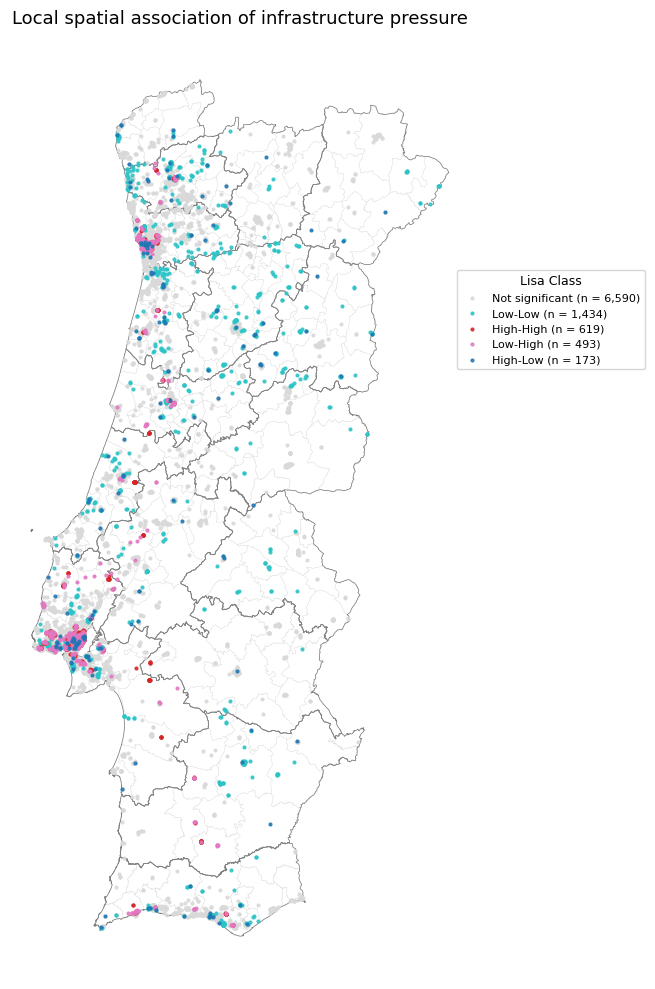

```python
munic.plot_categories_with_boundaries(
    gdf_points=gdf,
    gdf_mun=gdf_municipios,
    column="lisa_class",
    colors=LISA_COLORS,
    labels=LISA_LABELS_MAP,
    title="Local spatial association of infrastructure pressure",
    outfile="lisa_all_classes_nb05.png",
    #legend_title="LISA class"
)
```

#### 5.5.4 Mapa apenas das classes significativas

```python
gdf_lisa_significant = gdf[
    gdf["lisa_significant"]
].copy()
```

```python
LISA_SIGNIFICANT_COLORS = {
    "Low-Low": "#2ec4c7",
    "High-High": "#d62728",
    "Low-High": "#e377c2",
    "High-Low": "#1f77b4"
}
```

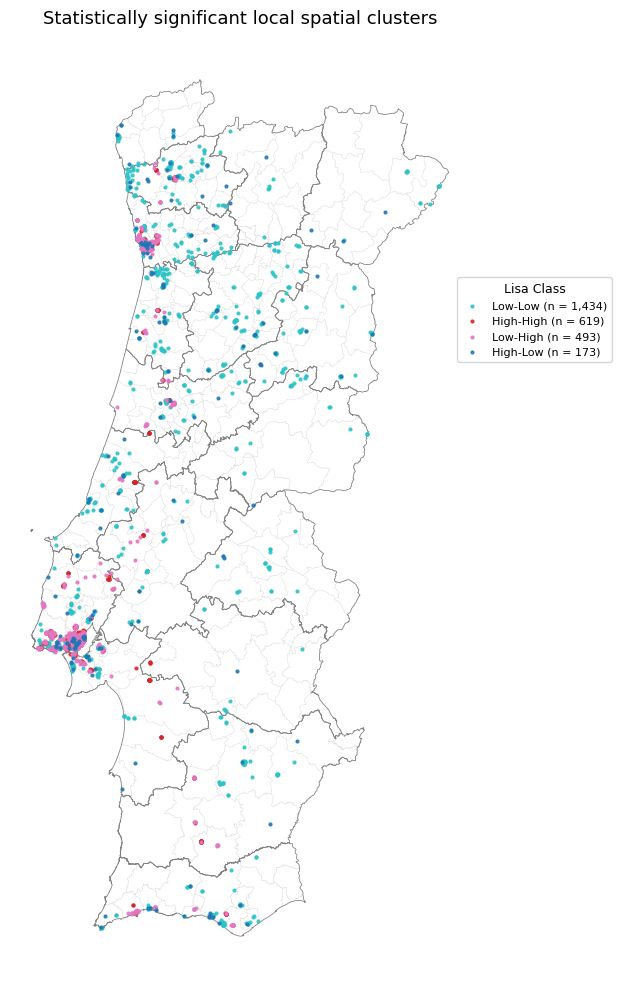

```python
munic.plot_categories_with_boundaries(
    gdf_points=gdf_lisa_significant,
    gdf_mun=gdf_municipios,
    column="lisa_class",
    colors=LISA_SIGNIFICANT_COLORS,
    labels=LISA_LABELS_MAP,
    title="Statistically significant local spatial clusters",
    outfile="lisa_significant_classes_nb05.png",
    #legend_title="LISA class"
)
```

```python
display(
    gdf_lisa_significant["lisa_class"]
    .value_counts()
    .reindex([
        "Low-Low",
        "High-High",
        "Low-High",
        "High-Low"
    ])
)
```

```
lisa_class
Low-Low      1434
High-High     619
Low-High      493
High-Low      173
Name: count, dtype: int64
```

### 5.5.5 Distribuição territorial dos High-High

```python
# validação dos HH
high_high = (
    gdf[
        gdf["lisa_class"] == "High-High"
    ]
    .copy()
)

print(len(high_high))
```

```
619
```

```python
hh_distritos = (
    high_high
    .groupby("distrito")
    .size()
    .sort_values(ascending=False)
    .rename("Stations")
    .reset_index()
)

hh_distritos["Percentage"] = (
    100
    * hh_distritos["Stations"]
    / len(high_high)
)

display(
    hh_distritos.round(2)
)
```

|  | distrito | Stations | Percentage |
| --- | --- | --- | --- |
| 0 | Lisboa | 304 | 49.11 |
| 1 | Porto | 110 | 17.77 |
| 2 | Setúbal | 54 | 8.72 |
| 3 | Faro | 32 | 5.17 |
| 4 | Braga | 26 | 4.20 |
| 5 | Coimbra | 25 | 4.04 |
| 6 | Beja | 23 | 3.72 |
| 7 | Leiria | 22 | 3.55 |
| 8 | Aveiro | 12 | 1.94 |
| 9 | Santarém | 7 | 1.13 |
| 10 | Évora | 4 | 0.65 |

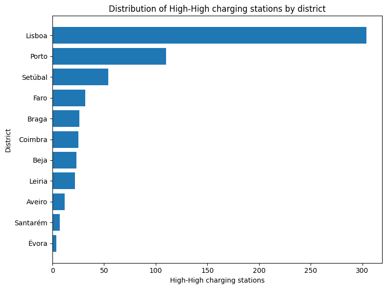

```python
plt.figure(figsize=(8,6))

plt.barh(
    hh_distritos["distrito"],
    hh_distritos["Stations"]
)

plt.gca().invert_yaxis()

plt.xlabel("High-High charging stations")
plt.ylabel("District")

plt.title(
    "Distribution of High-High charging stations by district"
)

plt.tight_layout()

plt.show()
```

```python
hh_municipios = (
    high_high
    .groupby("municipio")
    .size()
    .sort_values(ascending=False)
    .rename("Stations")
    .reset_index()
)

display(
    hh_municipios.head(20)
)
```

|  | municipio | Stations |
| --- | --- | --- |
| 0 | Lisboa | 145 |
| 1 | Matosinhos | 32 |
| 2 | Vila Nova de Gaia | 32 |
| 3 | Sintra | 31 |
| 4 | Loures | 27 |
| 5 | Porto | 25 |
| 6 | Amadora | 23 |
| 7 | Coimbra | 22 |
| 8 | Cascais | 21 |
| 9 | Oeiras | 19 |
| 10 | Braga | 19 |
| 11 | Leiria | 16 |
| 12 | Almada | 15 |
| 13 | Loulé | 15 |
| 14 | Odivelas | 13 |
| 15 | Torres Vedras | 13 |
| 16 | Almodôvar | 13 |
| 17 | Seixal | 12 |
| 18 | Lagos | 12 |
| 19 | Azambuja | 9 |

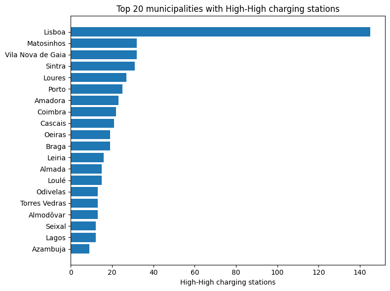

```python
top20 = hh_municipios.head(20)

plt.figure(figsize=(8,6))

plt.barh(
    top20["municipio"],
    top20["Stations"]
)

plt.gca().invert_yaxis()

plt.xlabel("High-High charging stations")

plt.title(
    "Top 20 municipalities with High-High charging stations"
)

plt.tight_layout()

plt.show()
```

# 5.6 Identificação de áreas prioritárias

*Identification of priority areas for charging infrastructure expansion*

#### 5.6.1 Definição dos limiares

```python
# ---------------------------------------------------
# Top 10% :: Percentil 90 (90th percentile)
# ---------------------------------------------------

limiar_pressao = (
    gdf["sessoes_por_evse_instalado"]
    .quantile(0.90)
)
limiar_kwh = (
    gdf["kwh_por_kw_instalado"]
    .quantile(0.90)
)
limiar_pressao, limiar_kwh
```

```
(np.float64(1096.7333333333336), np.float64(598.8635944055948))
```

#### 5.6.2 Seleção dos postos prioritários

```python
# ---------------------------------------------------
# Postos prioritários
# ---------------------------------------------------
postos_prioritarios = gdf[
    (
        gdf["sessoes_por_evse_instalado"] >= limiar_pressao
    )
    &
    (
        gdf["kwh_por_kw_instalado"] >= limiar_kwh
    )
    &
    (
        gdf["lisa_class"] == "High-High"
    )
].copy()


postos_prioritarios.shape
```

```
(185, 37)
```

#### 5.6.3 Resumo

```python
print(len(postos_prioritarios))

postos_prioritarios = anonymise_station_labels(postos_prioritarios)

display(
    postos_prioritarios[
        [
            "station_label",
            "distrito",
            "municipio",
            "cluster",
            "lisa_class",
            "sessoes_por_evse_instalado",
            "kwh_por_kw_instalado",
            "potencia_total_kw"
        ]
    ]
    .sort_values(
        "sessoes_por_evse_instalado",
        ascending=False
    )
    .head(30)
)
```

```
185
```

|  | station_label | distrito | municipio | cluster | lisa_class | sessoes_por_evse_instalado | kwh_por_kw_instalado | potencia_total_kw |
| --- | --- | --- | --- | --- | --- | --- | --- | --- |
| 610 | CS019 | Lisboa | Azambuja | 1 | High-High | 4542.000000 | 1234.739450 | 180.0 |
| 7102 | CS136 | Lisboa | Oeiras | 1 | High-High | 4275.000000 | 1512.658197 | 122.0 |
| 1363 | CS031 | Lisboa | Cascais | 0 | High-High | 4189.500000 | 3759.171409 | 22.0 |
| 9176 | CS183 | Porto | Vila Nova de Gaia | 1 | High-High | 4162.000000 | 1188.439301 | 143.0 |
| 7011 | CS131 | Lisboa | Oeiras | 0 | High-High | 4105.500000 | 1716.557318 | 44.0 |
| 7487 | CS142 | Porto | Porto | 1 | High-High | 3908.000000 | 666.038531 | 160.0 |
| 2797 | CS065 | Lisboa | Lisboa | 1 | High-High | 3904.333333 | 1459.307965 | 143.0 |
| 7010 | CS130 | Lisboa | Oeiras | 0 | High-High | 3829.000000 | 1571.509773 | 44.0 |
| 1413 | CS035 | Lisboa | Cascais | 1 | High-High | 3813.500000 | 1441.949180 | 122.0 |
| 2669 | CS052 | Lisboa | Lisboa | 1 | High-High | 3762.666667 | 954.152566 | 286.0 |
| 7008 | CS128 | Lisboa | Oeiras | 1 | High-High | 3682.000000 | 1160.997345 | 200.0 |
| 607 | CS017 | Lisboa | Azambuja | 1 | High-High | 3570.333333 | 1024.400503 | 143.0 |
| 432 | CS013 | Lisboa | Amadora | 1 | High-High | 3514.000000 | 1243.119800 | 150.0 |
| 2890 | CS081 | Lisboa | Lisboa | 1 | High-High | 3384.666667 | 1579.098308 | 143.0 |
| 7009 | CS129 | Lisboa | Oeiras | 1 | High-High | 3379.500000 | 1053.172310 | 200.0 |
| 1364 | CS032 | Lisboa | Cascais | 0 | High-High | 3334.000000 | 3161.968909 | 22.0 |
| 2844 | CS069 | Lisboa | Lisboa | 1 | High-High | 3259.000000 | 1204.306983 | 172.0 |
| 2891 | CS082 | Lisboa | Lisboa | 1 | High-High | 3221.000000 | 1482.895392 | 143.0 |
| 2525 | CS045 | Lisboa | Loures | 0 | High-High | 3207.500000 | 2118.741932 | 44.0 |
| 9089 | CS174 | Porto | Vila Nova de Gaia | 0 | High-High | 3204.000000 | 2175.402273 | 22.0 |
| 427 | CS012 | Lisboa | Amadora | 1 | High-High | 3183.333333 | 1476.751926 | 122.0 |
| 608 | CS018 | Lisboa | Azambuja | 1 | High-High | 3170.000000 | 736.214638 | 210.0 |
| 1411 | CS033 | Lisboa | Cascais | 1 | High-High | 3087.500000 | 888.749930 | 143.0 |
| 3036 | CS092 | Lisboa | Loures | 1 | High-High | 3084.333333 | 1465.258937 | 143.0 |
| 2524 | CS044 | Lisboa | Loures | 0 | High-High | 3044.000000 | 643.828159 | 132.0 |
| 3037 | CS093 | Lisboa | Loures | 1 | High-High | 3019.666667 | 1429.877091 | 143.0 |
| 7969 | CS154 | Lisboa | Sintra | 0 | High-High | 2998.000000 | 1823.192795 | 44.0 |
| 2889 | CS080 | Lisboa | Lisboa | 1 | High-High | 2987.333333 | 1419.405636 | 143.0 |
| 7578 | CS150 | Porto | Porto | 1 | High-High | 2950.000000 | 1396.845060 | 100.0 |
| 8220 | CS159 | Santarém | Santarém | 1 | High-High | 2948.750000 | 779.381567 | 420.0 |

#### 5.6.4 Distribuição territorial

```python
priority_summary = (
    postos_prioritarios["distrito"]
    .value_counts()
    .rename_axis("District")
    .reset_index(name="Stations")
)

priority_summary["Percentage"] = (
    100
    * priority_summary["Stations"]
    / len(postos_prioritarios)
)

display(priority_summary.round(2))
```

|  | District | Stations | Percentage |
| --- | --- | --- | --- |
| 0 | Lisboa | 114 | 61.62 |
| 1 | Porto | 43 | 23.24 |
| 2 | Setúbal | 7 | 3.78 |
| 3 | Coimbra | 6 | 3.24 |
| 4 | Faro | 6 | 3.24 |
| 5 | Braga | 4 | 2.16 |
| 6 | Santarém | 3 | 1.62 |
| 7 | Aveiro | 1 | 0.54 |
| 8 | Leiria | 1 | 0.54 |

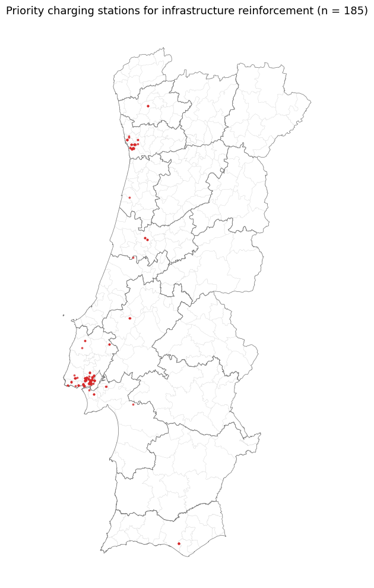

```python
munic.plot_categories_with_boundaries(
    gdf_points=postos_prioritarios,
    gdf_mun=gdf_municipios,
    column=None,
    title=(
        "Priority charging stations for "
        "infrastructure reinforcement"
        f" (n = {len(postos_prioritarios):,})"
    ),
    outfile="priority_areas_for_infrastructure_nb05_c4_5_6_04.png",
    point_color="#d62728"
)
```

### 5.7 Caracterização funcional dos postos

*Functional characterisation of priority stations*

```python
priority_operational_summary = (
    postos_prioritarios[
        [
            "sessoes_mes_ativo",
            "kwh_mes_ativo",
            "sessoes_por_evse_instalado",
            "kwh_por_kw_instalado",
            "n_evse_instalados",
            "n_conectores_instalados",
            "potencia_total_kw",
            "potencia_max_kw",
            "tem_dc",
            "tem_rapido"
        ]
    ]
    .describe()
    .round(2)
)

display(priority_operational_summary)
```

|  | sessoes_mes_ativo | kwh_mes_ativo | sessoes_por_evse_instalado | kwh_por_kw_instalado | n_evse_instalados | n_conectores_instalados | potencia_total_kw | potencia_max_kw | tem_dc | tem_rapido |
| --- | --- | --- | --- | --- | --- | --- | --- | --- | --- | --- |
| count | 185.00 | 185.00 | 185.00 | 185.00 | 185.00 | 185.00 | 185.00 | 185.00 | 185.00 | 185.00 |
| mean | 245.51 | 4816.48 | 2124.41 | 1242.14 | 2.24 | 2.32 | 95.36 | 38.27 | 0.47 | 0.44 |
| std | 146.31 | 3658.52 | 777.86 | 795.03 | 0.91 | 0.98 | 87.22 | 30.48 | 0.50 | 0.50 |
| min | 47.87 | 614.80 | 1101.00 | 611.53 | 1.00 | 1.00 | 7.40 | 3.70 | 0.00 | 0.00 |
| 25% | 123.48 | 1663.44 | 1497.50 | 771.20 | 2.00 | 2.00 | 22.00 | 22.00 | 0.00 | 0.00 |
| 50% | 219.96 | 3955.77 | 1928.33 | 1040.19 | 2.00 | 2.00 | 48.00 | 22.00 | 0.00 | 0.00 |
| 75% | 345.67 | 7019.36 | 2589.50 | 1429.88 | 3.00 | 3.00 | 143.00 | 50.00 | 1.00 | 1.00 |
| max | 682.14 | 18974.52 | 4542.00 | 6812.16 | 6.00 | 6.00 | 660.00 | 160.00 | 1.00 | 1.00 |

```python
# ---------------------------------------------------
# Comparar com a rede total
# ---------------------------------------------------

comparison_priority_network = pd.DataFrame({
    "Network median": gdf[
        [
            "sessoes_mes_ativo",
            "kwh_mes_ativo",
            "sessoes_por_evse_instalado",
            "kwh_por_kw_instalado",
            "potencia_total_kw",
            "n_evse_instalados"
        ]
    ].median(),

    "Priority stations median": postos_prioritarios[
        [
            "sessoes_mes_ativo",
            "kwh_mes_ativo",
            "sessoes_por_evse_instalado",
            "kwh_por_kw_instalado",
            "potencia_total_kw",
            "n_evse_instalados"
        ]
    ].median()
})

comparison_priority_network["Relative difference"] = (
    comparison_priority_network["Priority stations median"]
    / comparison_priority_network["Network median"]
)

display(comparison_priority_network.round(2))
```

|  | Network median | Priority stations median | Relative difference |
| --- | --- | --- | --- |
| sessoes_mes_ativo | 22.24 | 219.96 | 9.89 |
| kwh_mes_ativo | 413.61 | 3955.77 | 9.56 |
| sessoes_por_evse_instalado | 161.00 | 1928.33 | 11.98 |
| kwh_por_kw_instalado | 125.29 | 1040.19 | 8.30 |
| potencia_total_kw | 44.00 | 48.00 | 1.09 |
| n_evse_instalados | 2.00 | 2.00 | 1.00 |

```python
display(
    postos_prioritarios[
        ["tem_dc","tem_rapido"]
    ]
    .mean()
    .mul(100)
    .round(1)
    .rename("%")
    .to_frame()
)
```

|  | % |
| --- | --- |
| tem_dc | 47.0 |
| tem_rapido | 44.3 |

```python
display(
    postos_prioritarios["classe_pressao_observada"]
    .value_counts(normalize=True)
    .mul(100)
    .round(1)
    .rename("Percentage")
    .reset_index()
)
```

|  | classe_pressao_observada | Percentage |
| --- | --- | --- |
| 0 | Alta | 48.1 |
| 1 | Média | 44.3 |
| 2 | Muito Alta | 7.0 |
| 3 | Baixa | 0.5 |

#### 5.7.3 Distribuição pelos clusters K-Means

```python
cluster_priority = (
    postos_prioritarios["cluster"]
    .value_counts()
    .sort_index()
    .rename_axis("Cluster")
    .reset_index(name="Stations")
)

cluster_priority["Percentage"] = (
    100
    * cluster_priority["Stations"]
    / len(postos_prioritarios)
)

display(cluster_priority.round(2))
```

|  | Cluster | Stations | Percentage |
| --- | --- | --- | --- |
| 0 | 0 | 99 | 53.51 |
| 1 | 1 | 86 | 46.49 |

```python
# ---------------------------------------------------
# Nomes operacionais dos clusters definidos no NB04
# ---------------------------------------------------
CLUSTER_NAMES = {
    0: "Regular-use AC stations",
    1: "High-demand DC fast-charging stations",
    2: "Under-utilised working-hours stations",
    3: "Long-duration AC destination stations"
}

# Número total de postos em cada cluster
cluster_total = (
    gdf["cluster"]
    .value_counts()
    .sort_index()
)

# Número de postos prioritários em cada cluster
cluster_priority = (
    postos_prioritarios["cluster"]
    .value_counts()
    .sort_index()
)

priority_cluster_summary = pd.DataFrame({
    "Total stations": cluster_total,
    "Priority stations": cluster_priority
}).fillna(0)

priority_cluster_summary["Priority stations"] = (
    priority_cluster_summary["Priority stations"].astype(int)
)

# Peso de cada cluster no conjunto dos 185 postos prioritários
priority_cluster_summary["Priority composition (%)"] = (
    priority_cluster_summary["Priority stations"]
    / len(postos_prioritarios)
    * 100
)

# Percentagem dos postos de cada cluster que foi considerada prioritária
priority_cluster_summary["Priority rate within cluster (%)"] = (
    priority_cluster_summary["Priority stations"]
    / priority_cluster_summary["Total stations"]
    * 100
)

priority_cluster_summary["Operational profile"] = (
    priority_cluster_summary.index.map(CLUSTER_NAMES)
)

priority_cluster_summary = (
    priority_cluster_summary
    .reset_index(names="Cluster")
    [
        [
            "Cluster",
            "Operational profile",
            "Total stations",
            "Priority stations",
            "Priority composition (%)",
            "Priority rate within cluster (%)"
        ]
    ]
)

display(priority_cluster_summary.round(2))
```

|  | Cluster | Operational profile | Total stations | Priority stations | Priority composition (%) | Priority rate within cluster (%) |
| --- | --- | --- | --- | --- | --- | --- |
| 0 | 0 | Regular-use AC stations | 3636 | 99 | 53.51 | 2.72 |
| 1 | 1 | High-demand DC fast-charging stations | 2598 | 86 | 46.49 | 3.31 |
| 2 | 2 | Under-utilised working-hours stations | 1195 | 0 | 0.00 | 0.00 |
| 3 | 3 | Long-duration AC destination stations | 1880 | 0 | 0.00 | 0.00 |

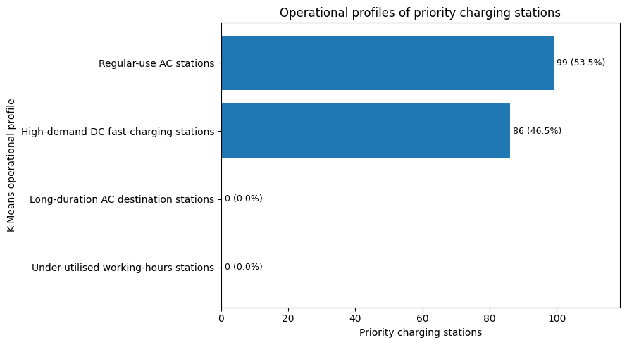

```python
priority_cluster_plot = (
    priority_cluster_summary
    .sort_values(
        "Priority stations",
        ascending=True
    )
)

fig, ax = plt.subplots(figsize=(9, 5))

bars = ax.barh(
    priority_cluster_plot["Operational profile"],
    priority_cluster_plot["Priority stations"]
)

for bar, n_stations, percentage in zip(
    bars,
    priority_cluster_plot["Priority stations"],
    priority_cluster_plot["Priority composition (%)"]
):
    ax.text(
        bar.get_width() + 1,
        bar.get_y() + bar.get_height() / 2,
        f"{n_stations} ({percentage:.1f}%)",
        va="center",
        fontsize=9
    )

ax.set_title(
    "Operational profiles of priority charging stations"
)
ax.set_xlabel("Priority charging stations")
ax.set_ylabel("K-Means operational profile")

ax.set_xlim(
    0,
    priority_cluster_plot["Priority stations"].max() * 1.20
)

plt.tight_layout()

fig.savefig(
    FIG_DIR / "priority_stations_by_kmeans_typology_nb05.png",
    dpi=300,
    bbox_inches="tight"
)

plt.show()
```

#### 5.7.4 Facilities

The following analysis characterises the facilities associated with the 185 priority stations and compares their prevalence with the complete charging network. These contextual variables are not used to define the priority stations.

```python
# ---------------------------------------------------
# Load facilities only once
# ---------------------------------------------------

facilities = read_sql("SELECT * FROM v60_facilities_posto")

facility_cols = [
    col for col in facilities.columns
    if col.startswith("tem_")
]

# Preserve one record per station
facilities = (
    facilities[
        ["id_charging_station"] + facility_cols
    ]
    .drop_duplicates("id_charging_station")
    .copy()
)

print(f"Facilities records: {len(facilities):,}")
print(f"Facility indicators: {len(facility_cols)}")
```

```
Facilities records: 16,993
Facility indicators: 19
```

```python
# ------------------------------------------------------------------------------------------------------
# Add only columns not already present in gdf, avoiding _x / _y duplicates
# ------------------------------------------------------------------------------------------------------
facility_cols_to_add = [
    col for col in facility_cols
    if col not in gdf.columns
]

if facility_cols_to_add:
    gdf = gdf.merge(
        facilities[
            ["id_charging_station"] + facility_cols_to_add
        ],
        on="id_charging_station",
        how="left",
        validate="one_to_one"
    )

# Rebuild the priority subset so that it inherits the contextual columns
postos_prioritarios = gdf.loc[
    gdf["id_charging_station"].isin(
        postos_prioritarios["id_charging_station"]
    )
].copy()

print("Facility columns available:", len([
    c for c in facility_cols if c in gdf.columns
]))
```

```
Facility columns available: 19
```

```python
facility_cols_available = [
    col for col in facility_cols
    if col in gdf.columns
]

facility_priority_comparison = pd.DataFrame({
    "Network (%)":
        gdf[facility_cols_available].mean() * 100,

    "Priority stations (%)":
        postos_prioritarios[facility_cols_available].mean() * 100
}).round(1)

facility_priority_comparison["Difference (pp)"] = (
    facility_priority_comparison["Priority stations (%)"]
    - facility_priority_comparison["Network (%)"]
)

facility_priority_comparison = (
    facility_priority_comparison
    .sort_values("Difference (pp)", ascending=False)
)

display(facility_priority_comparison.head(10))
```

|  | Network (%) | Priority stations (%) | Difference (pp) |
| --- | --- | --- | --- |
| tem_mall | 2.7 | 13.0 | 10.3 |
| tem_supermarket | 15.6 | 16.8 | 1.2 |
| tem_tram_stop | 0.0 | 0.0 | 0.0 |
| tem_metro_station | 0.1 | 0.0 | -0.1 |
| tem_wifi | 0.1 | 0.0 | -0.1 |
| tem_carpool_parking | 0.2 | 0.0 | -0.2 |
| tem_fuelstation | 6.3 | 5.9 | -0.4 |
| tem_bike_sharing | 0.9 | 0.5 | -0.4 |
| tem_museum | 0.4 | 0.0 | -0.4 |
| tem_taxi_stand | 0.4 | 0.0 | -0.4 |

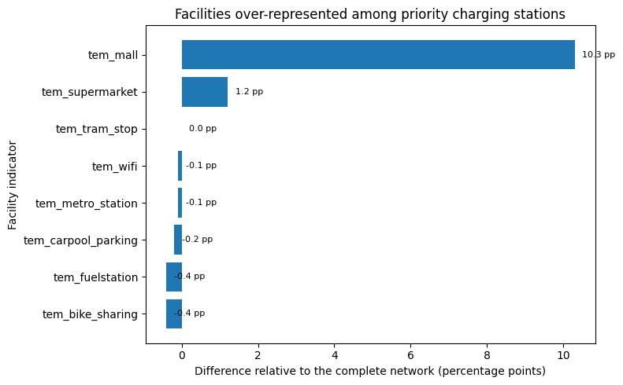

```python
facility_plot = (
    facility_priority_comparison
    .head(8)
    .sort_values("Difference (pp)", ascending=True)
)

fig, ax = plt.subplots(figsize=(8, 5))

bars = ax.barh(
    facility_plot.index,
    facility_plot["Difference (pp)"]
)

for bar, value in zip(
    bars,
    facility_plot["Difference (pp)"]
):
    ax.text(
        bar.get_width() + 0.2,
        bar.get_y() + bar.get_height() / 2,
        f"{value:.1f} pp",
        va="center",
        fontsize=8
    )

ax.set_title(
    "Facilities over-represented among priority charging stations"
)
ax.set_xlabel(
    "Difference relative to the complete network (percentage points)"
)
ax.set_ylabel("Facility indicator")

plt.tight_layout()

fig.savefig(
    FIG_DIR / "priority_stations_facilities_nb05.png",
    dpi=300,
    bbox_inches="tight"
)

plt.show()
```

#### 5.7.5 Parking

```python
parking = read_sql(
    "SELECT * FROM v61_parking_posto"
)

assert "parking_type" in parking.columns
assert parking["id_charging_station"].is_unique

parking = (
    parking[
        ["id_charging_station", "parking_type"]
    ]
    .copy()
)

if "parking_type" not in gdf.columns:
    gdf = gdf.merge(
        parking,
        on="id_charging_station",
        how="left",
        validate="one_to_one"
    )

# Rebuild the priority subset so it inherits parking_type
postos_prioritarios = gdf.loc[
    gdf["id_charging_station"].isin(
        postos_prioritarios["id_charging_station"]
    )
].copy()

display(
    parking["parking_type"]
    .value_counts(dropna=False)
)
```

```
parking_type
PARKING_LOT           7017
PARKING_GARAGE        4527
ON_STREET             3462
UNDERGROUND_GARAGE     857
NaN                    706
ALONG_MOTORWAY         366
ON_DRIVEWAY             58
Name: count, dtype: int64
```

The parking view has already been validated and merged in the preceding cell.

```python
display(
    postos_prioritarios["parking_type"]
    .value_counts(dropna=False)
)
```

```
parking_type
PARKING_LOT           127
ON_STREET              25
PARKING_GARAGE         24
UNDERGROUND_GARAGE      5
ALONG_MOTORWAY          4
Name: count, dtype: int64
```

```python
if "parking_type" in gdf.columns:
    parking_priority = pd.crosstab(
        postos_prioritarios["parking_type"],
        columns="Priority stations",
        normalize="columns"
    ).mul(100).round(1)

    parking_network = pd.crosstab(
        gdf["parking_type"],
        columns="Network",
        normalize="columns"
    ).mul(100).round(1)

    parking_comparison = (
        parking_network
        .join(parking_priority, how="outer")
        .fillna(0)
    )

    parking_comparison["Difference (pp)"] = (
        parking_comparison["Priority stations"]
        - parking_comparison["Network"]
    )

    display(
        parking_comparison
        .sort_values("Priority stations", ascending=False)
    )
else:
    print(
        "No 'parking_type' column was found in v61_parking_posto."
    )
```

| col_0 parking_type | Network | Priority stations | Difference (pp) |
| --- | --- | --- | --- |
| PARKING_LOT | 46.9 | 68.6 | 21.7 |
| ON_STREET | 17.1 | 13.5 | -3.6 |
| PARKING_GARAGE | 23.9 | 13.0 | -10.9 |
| UNDERGROUND_GARAGE | 4.3 | 2.7 | -1.6 |
| ALONG_MOTORWAY | 1.9 | 2.2 | 0.3 |
| NaN | 5.7 | 0.0 | -5.7 |
| ON_DRIVEWAY | 0.1 | 0.0 | -0.1 |

```python
# ---------------------------------------------------
#   Mapeamenento overleaf (EN)
# ---------------------------------------------------
PARKING_LABELS = {
    "PARKING_LOT": "Parking lot",
    "PARKING_GARAGE": "Parking garage",
    "UNDERGROUND_GARAGE": "Underground garage",
    "ON_STREET": "On-street parking",
    "ON_DRIVEWAY": "Private driveway",
    "ALONG_MOTORWAY": "Motorway service area",
    "NaN": "Unknown"
}
```

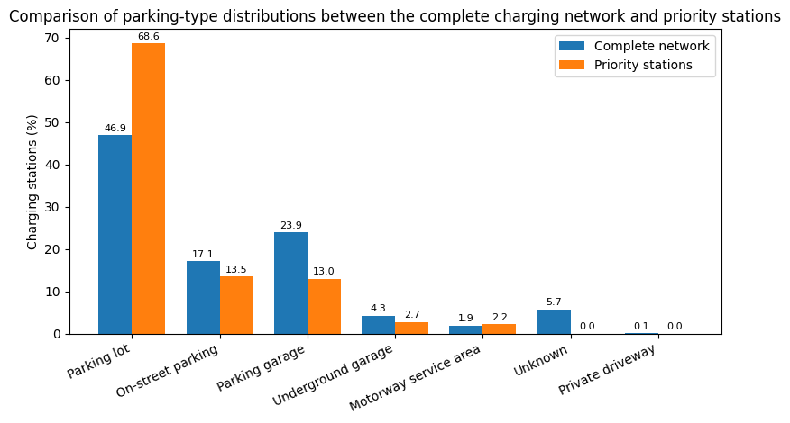

```python
parking_plot = (
    parking_comparison
    .reset_index()
    .rename(
        columns={
            "parking_type": "Parking type"
        }
    )
)

# Converter eventuais NaN reais em texto temporário
parking_plot["Parking type"] = (
    parking_plot["Parking type"]
    .fillna("Not specified")
    .replace(PARKING_LABELS)
)

# Remover categoria desconhecida da figura
"""parking_plot = parking_plot[
    parking_plot["Parking type"] != "Unknown"
].copy()
"""

# Ordenar pela percentagem nos postos prioritários
parking_plot = parking_plot.sort_values(
    "Priority stations",
    ascending=False
).reset_index(drop=True)

x = np.arange(len(parking_plot))
width = 0.38

fig, ax = plt.subplots(figsize=(8, 4.8))

bars_network = ax.bar(
    x - width / 2,
    parking_plot["Network"],
    width,
    label="Complete network"
)

bars_priority = ax.bar(
    x + width / 2,
    parking_plot["Priority stations"],
    width,
    label="Priority stations"
)

ax.set_xticks(
    x,
    parking_plot["Parking type"],
    rotation=25,
    ha="right"
)

ax.set_ylabel("Charging stations (%)")

ax.set_title("Comparison of parking-type distributions between the complete charging network and priority stations")

ax.legend()

ax.bar_label(
    bars_network,
    fmt="%.1f",
    padding=2,
    fontsize=8
)

ax.bar_label(
    bars_priority,
    fmt="%.1f",
    padding=2,
    fontsize=8
)

plt.tight_layout()

fig.savefig(
    FIG_DIR / "parking_type_network_priority_nb05.png",
    dpi=300,
    bbox_inches="tight"
)

plt.show()
```

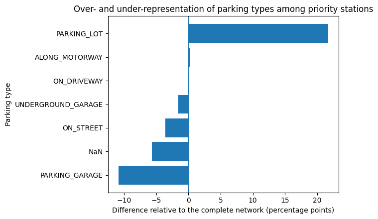

```python
parking_difference_plot = (
    parking_comparison["Difference (pp)"]
    .sort_values()
)

fig, ax = plt.subplots(figsize=(7, 4.5))

ax.barh(
    parking_difference_plot.index,
    parking_difference_plot.values
)

ax.axvline(
    0,
    linewidth=0.8
)
ax.set_title("Over- and under-representation of parking types among priority stations")
ax.set_xlabel("Difference relative to the complete network (percentage points)")
ax.set_ylabel("Parking type")

plt.tight_layout()
plt.show()
```

#### 5.7.6 Proximity to the road network

```python
vias_posto = read_sql(
    "SELECT * FROM v66_posto_rede_viaria_proxima"
)

road_cols = [
    "road_number",
    "categoria",
    "estado",
    "gestao",
    "n_vias",
    "dist_via_m"
]

vias_posto = (
    vias_posto[
        ["id_charging_station"] + [
            col for col in road_cols
            if col in vias_posto.columns
        ]
    ]
    .drop_duplicates("id_charging_station")
    .copy()
)

road_cols_to_add = [
    col for col in road_cols
    if col in vias_posto.columns
    and col not in gdf.columns
]

if road_cols_to_add:
    gdf = gdf.merge(
        vias_posto[
            ["id_charging_station"] + road_cols_to_add
        ],
        on="id_charging_station",
        how="left",
        validate="one_to_one"
    )

postos_prioritarios = gdf.loc[
    gdf["id_charging_station"].isin(
        postos_prioritarios["id_charging_station"]
    )
].copy()
```

```python
road_summary = pd.DataFrame({
    "Network median distance (m)":
        [gdf["dist_via_m"].median()],

    "Priority median distance (m)":
        [postos_prioritarios["dist_via_m"].median()],

    "Network mean distance (m)":
        [gdf["dist_via_m"].mean()],

    "Priority mean distance (m)":
        [postos_prioritarios["dist_via_m"].mean()]
}).round(2)

display(road_summary)

if "categoria" in gdf.columns:
    road_category_priority = pd.crosstab(
        postos_prioritarios["categoria"],
        columns="Priority stations",
        normalize="columns"
    ).mul(100).round(1)

    road_category_network = pd.crosstab(
        gdf["categoria"],
        columns="Network",
        normalize="columns"
    ).mul(100).round(1)

    road_category_comparison = (
        road_category_network
        .join(road_category_priority, how="outer")
        .fillna(0)
    )

    road_category_comparison["Difference (pp)"] = (
        road_category_comparison["Priority stations"]
        - road_category_comparison["Network"]
    )

    display(
        road_category_comparison
        .sort_values("Priority stations", ascending=False)
    )
```

|  | Network median distance (m) | Priority median distance (m) | Network mean distance (m) | Priority mean distance (m) |
| --- | --- | --- | --- | --- |
| 0 | 214.82 | 198.89 | 476.34 | 518.86 |

| col_0 categoria | Network | Priority stations | Difference (pp) |
| --- | --- | --- | --- |
| Ramos de Ligação | 17.4 | 49.7 | 32.3 |
| Estrada Nacional | 55.5 | 21.6 | -33.9 |
| Auto-estrada | 11.6 | 18.4 | 6.8 |
| Itinerário Principal | 4.5 | 6.5 | 2.0 |
| Itinerário Complementar | 2.4 | 3.2 | 0.8 |
| Estrada Regional | 8.6 | 0.5 | -8.1 |
| Caminho Paralelo | 0.0 | 0.0 | 0.0 |

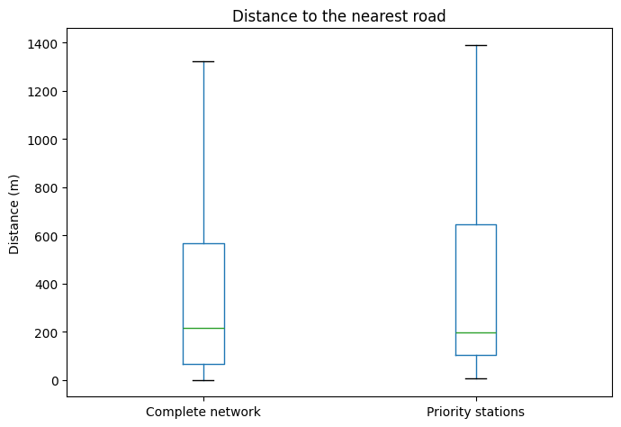

```python
# ------------------------------------------------------------------------------------------------------
# Representação com boxplot - Compara a distância à estrada mais próxima entre:
#     - todas as estações da rede
#     - e as classificadas como prioritárias
# ------------------------------------------------------------------------------------------------------

road_distance_plot = pd.concat(
    [
        pd.DataFrame({
            "Distance to nearest road (m)":
                gdf["dist_via_m"].dropna(),

            "Group":
                "Complete network"
        }),

        pd.DataFrame({
            "Distance to nearest road (m)":
                postos_prioritarios[
                    "dist_via_m"
                ].dropna(),

            "Group":
                "Priority stations"
        })
    ],
    ignore_index=True
)

fig, ax = plt.subplots(figsize=(7, 5))

road_distance_plot.boxplot(
    column="Distance to nearest road (m)",
    by="Group",
    ax=ax,
    showfliers=False,
    grid=False
)

ax.set_title(
    "Distance to the nearest road"
)
ax.set_xlabel("")
ax.set_ylabel("Distance (m)")

plt.suptitle("")
plt.tight_layout()

fig.savefig(
    FIG_DIR / "road_distance_priority_vs_network_nb05.png",
    dpi=300,
    bbox_inches="tight"
)

plt.show()
```

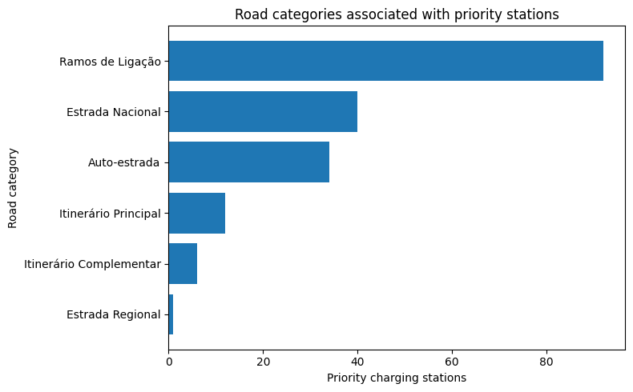

```python
priority_road_categories = (
    postos_prioritarios["categoria"]
    .value_counts()
    .rename_axis("Road category")
    .reset_index(name="Stations")
)

fig, ax = plt.subplots(figsize=(8, 5))

ax.barh(
    priority_road_categories["Road category"],
    priority_road_categories["Stations"]
)

ax.invert_yaxis()
ax.set_title("Road categories associated with priority stations")
ax.set_xlabel("Priority charging stations")
ax.set_ylabel("Road category")

plt.tight_layout()
plt.show()
```

```python
query_rede_viaria = """
    SELECT
        road_number,
        categoria,
        estado,
        gestao,
        n_vias,
        geom
    FROM rede_rodoviaria
"""

gdf_rede_viaria = read_gdf(
    query_rede_viaria,
    geom_col="geom"
)

gdf_rede_viaria = gdf_rede_viaria.to_crs(
    gdf.crs
)

print(gdf_rede_viaria.shape)
print(gdf_rede_viaria.geom_type.value_counts())
```

```
(4021, 6)
MultiLineString    2729
LineString         1292
Name: count, dtype: int64
```

```python
display(
    gdf_rede_viaria["categoria"]
    .value_counts(dropna=False)
)
```

```
categoria
Estrada Nacional           2194
Estrada Regional            620
Ramos de Ligação            586
Itinerário Complementar     268
Auto-estrada                247
Itinerário Principal         87
Caminho Paralelo             16
NaN                           2
Estrada Desclassificada       1
Name: count, dtype: int64
```

```python
categorias_mapa = [
    "Autoestrada",
    "Itinerário Principal",
    "Itinerário Complementar",
    "Estrada Nacional",
    "Estrada Regional"
]

gdf_vias_principais = gdf_rede_viaria[
    gdf_rede_viaria["categoria"].isin(
        categorias_mapa
    )
].copy()
```

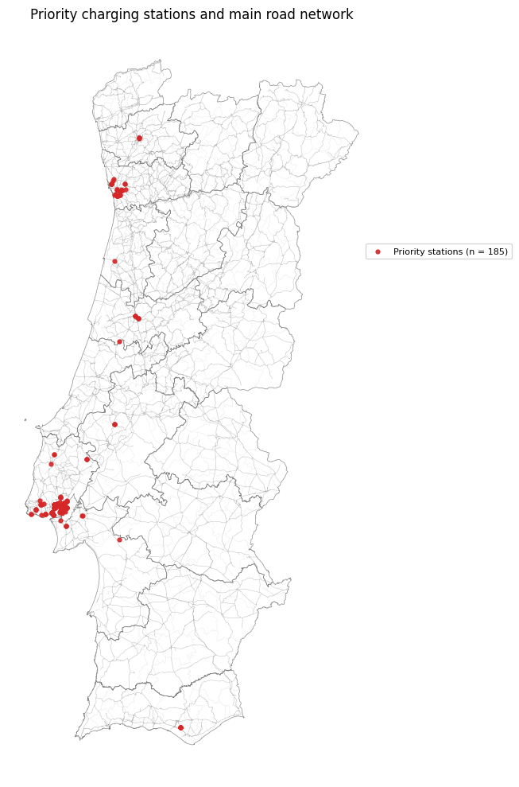

```python
fig, ax = plt.subplots(figsize=(8, 10))

# Municípios
gdf_municipios.boundary.plot(
    ax=ax,
    linewidth=0.12,
    color="#d3d3d3",
    alpha=0.6,
    zorder=1
)

# Distritos
gdf_municipios.dissolve(
    by="distrito"
).boundary.plot(
    ax=ax,
    linewidth=0.5,
    color="#777777",
    alpha=0.8,
    zorder=2
)

# Rede viária
gdf_vias_principais.plot(
    ax=ax,
    linewidth=0.35,
    color="#9e9e9e",
    alpha=0.65,
    zorder=3
)

# Postos prioritários
postos_prioritarios.plot(
    ax=ax,
    markersize=12,
    color="#d62728",
    alpha=0.9,
    label=(
        "Priority stations "
        f"(n = {len(postos_prioritarios):,})"
    ),
    zorder=4
)

ax.set_title(
    "Priority charging stations and main road network"
)

ax.legend(
    loc="center left",
    bbox_to_anchor=(0.96, 0.70),
    frameon=True,
    fontsize=8
)

ax.set_axis_off()

plt.tight_layout()

fig.savefig(
    FIG_DIR
    / "priority_stations_main_road_network_nb05.png",
    dpi=300,
    bbox_inches="tight"
)

plt.show()
```

```python
ROAD_STYLES = {
    "Auto-estrada": {
        "linewidth": 0.85,
        "alpha": 0.70
    },
    "Itinerário Principal": {
        "linewidth": 0.65,
        "alpha": 0.60
    },
    "Itinerário Complementar": {
        "linewidth": 0.50,
        "alpha": 0.50
    },
    "Estrada Nacional": {
        "linewidth": 0.25,
        "alpha": 0.30
    },
    "Estrada Regional": {
        "linewidth": 0.18,
        "alpha": 0.20
    }
}
```

```python
display(
    gdf_rede_viaria["categoria"]
    .value_counts(dropna=False)
)
```

```
categoria
Estrada Nacional           2194
Estrada Regional            620
Ramos de Ligação            586
Itinerário Complementar     268
Auto-estrada                247
Itinerário Principal         87
Caminho Paralelo             16
NaN                           2
Estrada Desclassificada       1
Name: count, dtype: int64
```

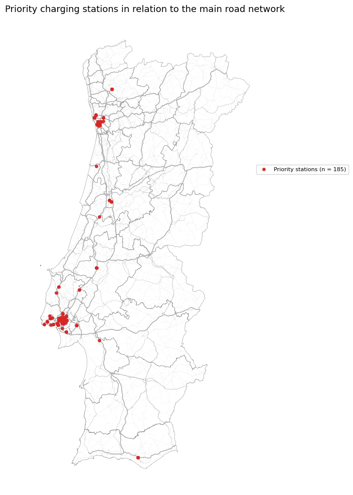

```python
fig, ax = plt.subplots(figsize=(8, 10))

# Limites municipais
gdf_municipios.boundary.plot(
    ax=ax,
    linewidth=0.10,
    color="#d9d9d9",
    alpha=0.45,
    zorder=1
)

# Limites distritais
gdf_municipios.dissolve(
    by="distrito"
).boundary.plot(
    ax=ax,
    linewidth=0.45,
    color="#7f7f7f",
    alpha=0.75,
    zorder=2
)

# Rede rodoviária principal
for categoria, style in ROAD_STYLES.items():

    subset = gdf_rede_viaria[
        gdf_rede_viaria["categoria"] == categoria
    ]

    if subset.empty:
        continue

    subset.plot(
        ax=ax,
        color="#9e9e9e",
        linewidth=style["linewidth"],
        alpha=style["alpha"],
        zorder=3
    )

# Postos prioritários
postos_prioritarios.plot(
    ax=ax,
    markersize=15,
    color="#d62728",
    alpha=0.95,
    label=(
        "Priority stations "
        f"(n = {len(postos_prioritarios):,})"
    ),
    zorder=4
)

ax.set_title(
    "Priority charging stations in relation to the main road network",
    fontsize=13,
    pad=10
)

# Legenda apenas dos postos
ax.legend(
    loc="center left",
    bbox_to_anchor=(0.97, 0.68),
    frameon=True,
    fontsize=8
)

ax.set_axis_off()

plt.tight_layout()

fig.savefig(
    FIG_DIR / "priority_stations_main_road_network_nb05.png",
    dpi=300,
    bbox_inches="tight"
)

plt.show()
```

## 5.8 Relationship between K-Means typologies and LISA patterns

This section uses the national K-Means labels already imported from NB04. The clusters must not be merged again.

```python
cluster_lisa_counts = pd.crosstab(
    gdf["cluster"],
    gdf["lisa_class"]
)

cluster_lisa_pct = (
    pd.crosstab(
        gdf["cluster"],
        gdf["lisa_class"],
        normalize="index"
    )
    .mul(100)
    .round(2)
)

display(cluster_lisa_counts)
display(cluster_lisa_pct)
```

| lisa_class cluster | High-High | High-Low | Low-High | Low-Low | Not significant |
| --- | --- | --- | --- | --- | --- |
| 0 | 276 | 70 | 120 | 571 | 2599 |
| 1 | 340 | 99 | 78 | 179 | 1902 |
| 2 | 0 | 0 | 89 | 368 | 738 |
| 3 | 3 | 4 | 206 | 316 | 1351 |

| lisa_class cluster | High-High | High-Low | Low-High | Low-Low | Not significant |
| --- | --- | --- | --- | --- | --- |
| 0 | 7.59 | 1.93 | 3.30 | 15.70 | 71.48 |
| 1 | 13.09 | 3.81 | 3.00 | 6.89 | 73.21 |
| 2 | 0.00 | 0.00 | 7.45 | 30.79 | 61.76 |
| 3 | 0.16 | 0.21 | 10.96 | 16.81 | 71.86 |

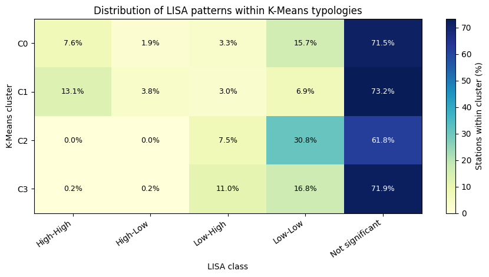

```python
cluster_lisa_report = (
    cluster_lisa_pct
    .reindex(
        columns=[
            "High-High",
            "High-Low",
            "Low-High",
            "Low-Low",
            "Not significant"
        ]
    )
)

values = cluster_lisa_report.values

fig, ax = plt.subplots(figsize=(9, 4.8))

im = ax.imshow(
    values,
    aspect="auto",
    cmap="YlGnBu"
)

ax.set_xticks(
    range(len(cluster_lisa_report.columns)),
    labels=cluster_lisa_report.columns,
    rotation=35,
    ha="right"
)

ax.set_yticks(
    range(len(cluster_lisa_report.index)),
    labels=[
        f"C{cluster_id}"
        for cluster_id in cluster_lisa_report.index
    ]
)

norm = im.norm

for i in range(values.shape[0]):
    for j in range(values.shape[1]):
        value = values[i, j]

        ax.text(
            j,
            i,
            f"{value:.1f}%",
            ha="center",
            va="center",
            fontsize=9,
            color=(
                "white"
                if norm(value) > 0.55
                else "black"
            )
        )

ax.set_title(
    "Distribution of LISA patterns within K-Means typologies"
)
ax.set_xlabel("LISA class")
ax.set_ylabel("K-Means cluster")

fig.colorbar(
    im,
    ax=ax,
    label="Stations within cluster (%)"
)

plt.tight_layout()

fig.savefig(
    FIG_DIR / "kmeans_lisa_cross_analysis_nb05.png",
    dpi=300,
    bbox_inches="tight"
)

plt.show()
```

```python
# -------------------------------------------------
# Distribuição nacional dos clusters
# -------------------------------------------------
cluster_network_pct = (
    gdf["cluster"]
    .value_counts(normalize=True)
    .sort_index()
    .mul(100)
)

# Distribuição dos clusters apenas para os hotspots High-High
cluster_hh_pct = (
    gdf.loc[
        gdf["lisa_class"] == "High-High",
        "cluster"
    ]
    .value_counts(normalize=True)
    .sort_index()
    .mul(100)
)

cluster_hh_comparison = pd.DataFrame({
    "National distribution (%)": cluster_network_pct,
    "High-High distribution (%)": cluster_hh_pct
}).fillna(0)

cluster_hh_comparison["Difference (pp)"] = (
    cluster_hh_comparison["High-High distribution (%)"]
    - cluster_hh_comparison["National distribution (%)"]
)

cluster_hh_comparison.index = [
    f"C{cluster_id}"
    for cluster_id in cluster_hh_comparison.index
]

display(
    cluster_hh_comparison.round(2)
)
```

|  | National distribution (%) | High-High distribution (%) | Difference (pp) |
| --- | --- | --- | --- |
| C0 | 39.06 | 44.59 | 5.53 |
| C1 | 27.91 | 54.93 | 27.02 |
| C2 | 12.84 | 0.00 | -12.84 |
| C3 | 20.20 | 0.48 | -19.71 |

## 5.9 Territorial context: population, charging supply and road coverage

```python
pop = read_sql(
    '''
    SELECT
        dtmn,
        populacao_total,
        densidade_pop_km2,
        postos_1000_hab,
        postos_10000_hab,
        evse_10000_hab,
        kw_10000_hab
    FROM v42_cobertura_populacional
    '''
)

via = read_sql(
    "SELECT * FROM v43_cobertura_viaria"
)

municipios = (
    via
    .merge(
        pop,
        on="dtmn",
        how="left",
        validate="one_to_one"
    )
)

print(f"Municipalities: {len(municipios):,}")
display(municipios.head())
```

```
Municipalities: 278
```

|  | dtmn | municipio | distrito | nuts_3 | nuts_2 | nuts_1 | n_postos | n_evse_raw | n_conectores | potencia_total_kw | ... | postos_por_km_via | evse_por_km_via | kw_por_km_via | geom | populacao_total | densidade_pop_km2 | postos_1000_hab | postos_10000_hab | evse_10000_hab | kw_10000_hab |
| --- | --- | --- | --- | --- | --- | --- | --- | --- | --- | --- | --- | --- | --- | --- | --- | --- | --- | --- | --- | --- | --- |
| 0 | 0101 | Águeda | Aveiro | Região de Aveiro | Centro | Continente | 32 | 75 | 78 | 3084.80 | ... | 0.207822 | 0.487082 | 20.034021 | 0106000020B30E0000010000000103000000010000001B... | 46119 | 137.555984 | 0.693857 | 6.938572 | 16.262278 | 668.878336 |
| 1 | 0102 | Albergaria-a-Velha | Aveiro | Região de Aveiro | Centro | Continente | 32 | 71 | 69 | 5521.20 | ... | 0.215250 | 0.477586 | 37.138686 | 0106000020B30E0000010000000103000000010000008E... | 24840 | 156.398552 | 1.288245 | 12.882448 | 28.582931 | 2222.705314 |
| 2 | 0103 | Anadia | Aveiro | Região de Aveiro | Centro | Continente | 32 | 81 | 84 | 5708.80 | ... | 0.245824 | 0.622242 | 43.854991 | 0106000020B30E00000100000001030000000100000082... | 27532 | 127.089461 | 1.162284 | 11.622839 | 29.420311 | 2073.514456 |
| 3 | 0104 | Arouca | Aveiro | Área Metropolitana do Porto | Norte | Continente | 7 | 18 | 18 | 722.00 | ... | 0.057786 | 0.148593 | 5.960232 | 0106000020B30E000001000000010300000001000000F3... | 21146 | 64.253011 | 0.331032 | 3.310319 | 8.512248 | 341.435733 |
| 4 | 0105 | Aveiro | Aveiro | Região de Aveiro | Centro | Continente | 143 | 297 | 305 | 28417.66 | ... | 0.914716 | 1.899794 | 181.776795 | 0106000020B30E0000010000000103000000010000009B... | 80954 | 409.736622 | 1.766435 | 17.664353 | 36.687502 | 3510.346617 |

5 rows × 24 columns

```python
municipal_indicators = [
    "n_postos",
    "n_evse_raw",
    "potencia_total_kw",
    "km_via_total",
    "postos_por_km_via",
    "densidade_pop_km2",
    "postos_10000_hab",
    "evse_10000_hab",
    "kw_10000_hab"
]

display(
    municipios[municipal_indicators]
    .describe()
    .round(2)
)
```

|  | n_postos | n_evse_raw | potencia_total_kw | km_via_total | postos_por_km_via | densidade_pop_km2 | postos_10000_hab | evse_10000_hab | kw_10000_hab |
| --- | --- | --- | --- | --- | --- | --- | --- | --- | --- |
| count | 278.00 | 278.00 | 278.00 | 278.00 | 278.00 | 278.00 | 278.00 | 278.00 | 278.00 |
| mean | 59.98 | 118.19 | 6496.23 | 114.85 | 0.51 | 305.06 | 13.79 | 31.02 | 1865.83 |
| std | 197.49 | 337.65 | 12986.83 | 74.66 | 1.62 | 838.85 | 16.69 | 33.91 | 2619.58 |
| min | 1.00 | 2.00 | 44.00 | 14.63 | 0.01 | 4.39 | 2.00 | 4.00 | 150.01 |
| 25% | 6.00 | 14.25 | 614.75 | 62.77 | 0.08 | 23.00 | 7.59 | 17.75 | 686.56 |
| 50% | 16.00 | 38.00 | 1834.95 | 91.83 | 0.18 | 64.73 | 10.95 | 25.42 | 1221.37 |
| 75% | 46.50 | 104.00 | 7146.29 | 146.08 | 0.41 | 170.14 | 15.26 | 35.31 | 1977.45 |
| max | 2892.00 | 4884.00 | 128721.82 | 403.68 | 24.21 | 7208.58 | 253.13 | 512.35 | 27951.77 |

```python
coverage_columns = [
    "municipio",
    "distrito",
    "n_postos",
    "postos_10000_hab",
    "evse_10000_hab",
    "kw_10000_hab",
    "postos_por_km_via"
]

top_coverage = (
    municipios[coverage_columns]
    .sort_values(
        "postos_10000_hab",
        ascending=False
    )
    .head(20)
)

bottom_coverage = (
    municipios[coverage_columns]
    .sort_values(
        "postos_10000_hab",
        ascending=True
    )
    .head(20)
)

display(top_coverage)
display(bottom_coverage)
```

|  | municipio | distrito | n_postos | postos_10000_hab | evse_10000_hab | kw_10000_hab | postos_por_km_via |
| --- | --- | --- | --- | --- | --- | --- | --- |
| 68 | Vila de Rei | Castelo Branco | 83 | 253.125953 | 512.351327 | 11218.664227 | 1.615321 |
| 221 | Grândola | Setúbal | 78 | 56.431775 | 136.738533 | 11721.185067 | 0.313285 |
| 152 | Lisboa | Lisboa | 2892 | 52.986830 | 89.483983 | 2358.423733 | 24.207446 |
| 156 | Oeiras | Lisboa | 879 | 51.206469 | 75.440702 | 5236.401042 | 6.891473 |
| 63 | Idanha-a-Nova | Castelo Branco | 37 | 44.284859 | 55.056852 | 2444.045482 | 0.159798 |
| 19 | Aljustrel | Beja | 35 | 39.441064 | 86.770340 | 27951.769213 | 0.266202 |
| 108 | Loulé | Faro | 273 | 37.742631 | 80.600564 | 4090.941769 | 1.093504 |
| 151 | Cascais | Lisboa | 795 | 37.128019 | 67.484261 | 2181.644748 | 5.010537 |
| 163 | Alter do Chão | Portalegre | 11 | 36.136662 | 88.699080 | 3740.473062 | 0.161695 |
| 218 | Alcochete | Setúbal | 68 | 35.522123 | 66.865173 | 4171.603197 | 1.052041 |
| 217 | Alcácer do Sal | Setúbal | 39 | 35.097192 | 84.593233 | 16442.044636 | 0.136755 |
| 141 | Nazaré | Leiria | 52 | 34.943888 | 96.767690 | 14409.112291 | 0.714297 |
| 101 | Albufeira | Faro | 154 | 34.870030 | 79.702925 | 2780.001811 | 1.562988 |
| 148 | Arruda dos Vinhos | Lisboa | 45 | 32.161235 | 50.743282 | 1873.070326 | 0.767781 |
| 229 | Sines | Setúbal | 44 | 30.990280 | 63.389210 | 3146.922102 | 0.484583 |
| 115 | Vila do Bispo | Faro | 17 | 29.735875 | 68.217597 | 4060.171419 | 0.323855 |
| 102 | Alcoutim | Faro | 7 | 27.744748 | 55.489497 | 1220.768926 | 0.087225 |
| 142 | Óbidos | Leiria | 33 | 27.679919 | 54.521054 | 6008.136219 | 0.420155 |
| 124 | Manteigas | Guarda | 8 | 27.500859 | 82.502578 | 1365.417669 | 0.160341 |
| 69 | Vila Velha de Ródão | Castelo Branco | 9 | 27.397260 | 63.926941 | 11823.439878 | 0.055706 |

|  | municipio | distrito | n_postos | postos_10000_hab | evse_10000_hab | kw_10000_hab | postos_por_km_via |
| --- | --- | --- | --- | --- | --- | --- | --- |
| 249 | Boticas | Vila Real | 1 | 2.000000 | 4.000000 | 176.000000 | 0.016878 |
| 264 | Castro Daire | Viseu | 3 | 2.184042 | 8.736168 | 509.609785 | 0.018285 |
| 234 | Paredes de Coura | Viana do Castelo | 2 | 2.316960 | 6.950880 | 152.919370 | 0.025093 |
| 86 | Vila Nova de Poiares | Coimbra | 2 | 2.939879 | 8.819638 | 323.386741 | 0.061831 |
| 208 | Mação | Santarém | 2 | 3.124024 | 9.372071 | 206.185567 | 0.013782 |
| 3 | Arouca | Aveiro | 7 | 3.310319 | 8.512248 | 341.435733 | 0.057786 |
| 173 | Monforte | Portalegre | 1 | 3.342246 | 13.368984 | 294.117647 | 0.013129 |
| 126 | Pinhel | Guarda | 3 | 3.707365 | 12.357884 | 271.873455 | 0.025544 |
| 5 | Castelo de Paiva | Aveiro | 6 | 3.849609 | 11.548826 | 590.273322 | 0.062858 |
| 58 | Vinhais | Bragança | 3 | 3.861998 | 6.436663 | 410.659114 | 0.020827 |
| 87 | Alandroal | Évora | 2 | 3.988831 | 11.966494 | 263.262864 | 0.035589 |
| 259 | Valpaços | Vila Real | 6 | 4.081355 | 11.563839 | 337.392014 | 0.049726 |
| 33 | Amares | Braga | 8 | 4.302232 | 9.680022 | 321.322936 | 0.178188 |
| 265 | Cinfães | Viseu | 8 | 4.512126 | 11.844332 | 391.539763 | 0.111421 |
| 28 | Moura | Beja | 6 | 4.525569 | 10.559662 | 365.062604 | 0.038917 |
| 235 | Ponte da Barca | Viana do Castelo | 5 | 4.527345 | 15.392974 | 272.546179 | 0.101920 |
| 244 | Sátão | Viseu | 5 | 4.533092 | 11.786038 | 576.609248 | 0.103565 |
| 121 | Fornos de Algodres | Guarda | 2 | 4.542357 | 13.627072 | 299.795594 | 0.031323 |
| 56 | Vila Flor | Bragança | 3 | 4.958678 | 16.528926 | 909.090909 | 0.021869 |
| 166 | Campo Maior | Portalegre | 4 | 4.973887 | 17.408605 | 382.989306 | 0.098882 |

## 5.10 Sensitivity analysis excluding Lisbon and Porto

The national K-Means labels are retained. Spatial weights, Global Moran's I, LISA and priority thresholds are recalculated for the reduced territory.

```python
# -------------------------------------------------
# Análise sem Lisboa e Porto
# -------------------------------------------------
EXCLUDED_DISTRICTS = ["LISBOA", "PORTO"]

gdf_sem_lp = gdf[
    ~gdf["distrito"]
    .str.upper()
    .isin(EXCLUDED_DISTRICTS)
].copy()

print(f"National network: {len(gdf):,}")
print(
    "Without Lisbon and Porto: "
    f"{len(gdf_sem_lp):,}"
)
```

```
National network: 9,309
Without Lisbon and Porto: 4,525
```

```python
import warnings
from libpysal.weights import KNN
from esda.moran import Moran, Moran_Local


def find_minimum_connected_k(
    gdf_input,
    k_start=1,
    k_max=30
):
    """Return the minimum KNN value that produces one connected component."""

    for k_value in range(k_start, k_max + 1):

        with warnings.catch_warnings():
            warnings.filterwarnings(
                "ignore",
                message="The weights matrix is not fully connected"
            )

            weights = KNN.from_dataframe(
                gdf_input,
                k=k_value
            )

        if weights.n_components == 1:
            weights.transform = "R"
            return k_value, weights

    raise ValueError(
        "No fully connected KNN matrix found "
        f"between k={k_start} and k={k_max}."
    )


k_sem_lp, w_sem_lp = find_minimum_connected_k(
    gdf_sem_lp,
    k_start=1,
    k_max=30
)

print(
    "Minimum connected neighbourhood "
    f"without Lisbon and Porto: k={k_sem_lp}"
)
```

```
Minimum connected neighbourhood without Lisbon and Porto: k=13
```

```python
moran_sem_lp_rows = []

for variable in MORAN_VARS:
    moran_sem_lp = Moran(
        gdf_sem_lp[variable].to_numpy(),
        w_sem_lp,
        permutations=999
    )

    moran_sem_lp_rows.append({
        "Indicator": MORAN_LABELS.get(
            variable,
            variable
        ),
        "Moran's I": moran_sem_lp.I,
        "p-value": moran_sem_lp.p_sim
    })

moran_sem_lp_df = pd.DataFrame(
    moran_sem_lp_rows
)

display(moran_sem_lp_df.round(4))
```

|  | Indicator | Moran's I | p-value |
| --- | --- | --- | --- |
| 0 | Sessions per active month | 0.1727 | 0.001 |
| 1 | Sessions per installed EVSE | 0.2508 | 0.001 |
| 2 | Energy per installed kW | 0.1188 | 0.001 |

```python
lisa_sem_lp = Moran_Local(
    gdf_sem_lp[LISA_VAR].to_numpy(),
    w_sem_lp,
    permutations=999,
    seed=42
)

gdf_sem_lp["lisa_quadrant"] = lisa_sem_lp.q
gdf_sem_lp["lisa_pvalue"] = lisa_sem_lp.p_sim
gdf_sem_lp["lisa_significant"] = (
    gdf_sem_lp["lisa_pvalue"] < 0.05
)

gdf_sem_lp["lisa_class"] = (
    gdf_sem_lp["lisa_quadrant"]
    .map(LISA_LABELS)
)

gdf_sem_lp.loc[
    ~gdf_sem_lp["lisa_significant"],
    "lisa_class"
] = "Not significant"

lisa_sem_lp_summary = (
    gdf_sem_lp["lisa_class"]
    .value_counts()
    .reindex(lisa_order)
    .rename_axis("Class")
    .reset_index(name="Stations")
)

lisa_sem_lp_summary["Percentage"] = (
    lisa_sem_lp_summary["Stations"]
    / len(gdf_sem_lp)
    * 100
)

display(lisa_sem_lp_summary.round(2))
```

|  | Class | Stations | Percentage |
| --- | --- | --- | --- |
| 0 | Not significant | 3458 | 76.42 |
| 1 | Low-Low | 445 | 9.83 |
| 2 | High-High | 287 | 6.34 |
| 3 | Low-High | 237 | 5.24 |
| 4 | High-Low | 98 | 2.17 |

```python
# --------------------------------------------------
# Priority stations — excluding Lisbon and Porto
# P90 thresholds recalculated within the reduced territory
# --------------------------------------------------

limiar_pressao_sem_lp = (
    gdf_sem_lp["sessoes_por_evse_instalado"]
    .quantile(0.90)
)

limiar_kwh_sem_lp = (
    gdf_sem_lp["kwh_por_kw_instalado"]
    .quantile(0.90)
)

postos_prioritarios_sem_lp = gdf_sem_lp[
    (gdf_sem_lp["lisa_class"] == "High-High")
    &
    (
        gdf_sem_lp["sessoes_por_evse_instalado"]
        >= limiar_pressao_sem_lp
    )
    &
    (
        gdf_sem_lp["kwh_por_kw_instalado"]
        >= limiar_kwh_sem_lp
    )
].copy()

print(f"Stations in reduced network: {len(gdf_sem_lp):,}")
print(f"P90 sessions/EVSE: {limiar_pressao_sem_lp:.2f}")
print(f"P90 kWh/kW: {limiar_kwh_sem_lp:.2f}")
print(
    f"Priority stations without Lisbon and Porto: "
    f"{len(postos_prioritarios_sem_lp):,}"
)
```

```
Stations in reduced network: 4,525
P90 sessions/EVSE: 880.03
P90 kWh/kW: 486.52
Priority stations without Lisbon and Porto: 63
```

```python
# --------------------------------------------------
# District representation after excluding Lisbon and Porto
# --------------------------------------------------

district_representation_sem_lp = (
    gdf_sem_lp
    .groupby("distrito")
    .agg(
        Stations=("id_charging_station", "nunique")
    )
    .reset_index()
)

district_representation_sem_lp["Station share (%)"] = (
    district_representation_sem_lp["Stations"]
    / len(gdf_sem_lp)
    * 100
)

priority_by_district_sem_lp = (
    postos_prioritarios_sem_lp
    .groupby("distrito")
    .size()
    .rename("Priority stations")
    .reset_index()
)

district_representation_sem_lp = (
    district_representation_sem_lp
    .merge(
        priority_by_district_sem_lp,
        on="distrito",
        how="left"
    )
)

district_representation_sem_lp["Priority stations"] = (
    district_representation_sem_lp["Priority stations"]
    .fillna(0)
    .astype(int)
)

district_representation_sem_lp["Priority share (%)"] = (
    district_representation_sem_lp["Priority stations"]
    / len(postos_prioritarios_sem_lp)
    * 100
)

district_representation_sem_lp["Priority vs network (pp)"] = (
    district_representation_sem_lp["Priority share (%)"]
    - district_representation_sem_lp["Station share (%)"]
)

district_representation_sem_lp = (
    district_representation_sem_lp
    .sort_values(
        "Priority stations",
        ascending=False
    )
)

display(
    district_representation_sem_lp.round(2)
)
```

|  | distrito | Stations | Station share (%) | Priority stations | Priority share (%) | Priority vs network (pp) |
| --- | --- | --- | --- | --- | --- | --- |
| 11 | Setúbal | 817 | 18.06 | 16 | 25.40 | 7.34 |
| 5 | Coimbra | 285 | 6.30 | 14 | 22.22 | 15.92 |
| 6 | Faro | 586 | 12.95 | 12 | 19.05 | 6.10 |
| 2 | Braga | 536 | 11.85 | 8 | 12.70 | 0.85 |
| 8 | Leiria | 405 | 8.95 | 5 | 7.94 | -1.01 |
| 0 | Aveiro | 437 | 9.66 | 4 | 6.35 | -3.31 |
| 10 | Santarém | 317 | 7.01 | 3 | 4.76 | -2.24 |
| 1 | Beja | 138 | 3.05 | 1 | 1.59 | -1.46 |
| 3 | Bragança | 62 | 1.37 | 0 | 0.00 | -1.37 |
| 4 | Castelo Branco | 133 | 2.94 | 0 | 0.00 | -2.94 |
| 7 | Guarda | 97 | 2.14 | 0 | 0.00 | -2.14 |
| 9 | Portalegre | 69 | 1.52 | 0 | 0.00 | -1.52 |
| 12 | Viana do Castelo | 154 | 3.40 | 0 | 0.00 | -3.40 |
| 13 | Vila Real | 111 | 2.45 | 0 | 0.00 | -2.45 |
| 14 | Viseu | 236 | 5.22 | 0 | 0.00 | -5.22 |
| 15 | Évora | 142 | 3.14 | 0 | 0.00 | -3.14 |

```python
"""
[col for col in [
    "n_sessoes",
    "energia_total_kwh",
    "sessoes_mes_ativo",
    "kwh_mes_ativo"
] if col in gdf_sem_lp.columns]
"""
```

```
'\n[col for col in [\n    "n_sessoes",\n    "energia_total_kwh",\n    "sessoes_mes_ativo",\n    "kwh_mes_ativo"\n] if col in gdf_sem_lp.columns]\n'
```

```python
# --------------------------------------------------
# District representation of demand and energy
# after excluding Lisbon and Porto
# --------------------------------------------------

district_activity_sem_lp = (
    gdf_sem_lp
    .groupby("distrito")
    .agg(
        Stations=("id_charging_station", "nunique"),
        Sessions=("n_sessoes", "sum"),
        Energy_kWh=("energia_total_kwh", "sum")
    )
    .reset_index()
)

# Share of the remaining charging network
district_activity_sem_lp["Station share (%)"] = (
    district_activity_sem_lp["Stations"]
    / district_activity_sem_lp["Stations"].sum()
    * 100
)

# Share of charging sessions
district_activity_sem_lp["Session share (%)"] = (
    district_activity_sem_lp["Sessions"]
    / district_activity_sem_lp["Sessions"].sum()
    * 100
)

# Share of delivered energy
district_activity_sem_lp["Energy share (%)"] = (
    district_activity_sem_lp["Energy_kWh"]
    / district_activity_sem_lp["Energy_kWh"].sum()
    * 100
)

# Priority stations by district
priority_by_district = (
    postos_prioritarios_sem_lp
    .groupby("distrito")
    .size()
    .rename("Priority stations")
    .reset_index()
)

district_activity_sem_lp = (
    district_activity_sem_lp
    .merge(
        priority_by_district,
        on="distrito",
        how="left"
    )
)

district_activity_sem_lp["Priority stations"] = (
    district_activity_sem_lp["Priority stations"]
    .fillna(0)
    .astype(int)
)

district_activity_sem_lp["Priority share (%)"] = (
    district_activity_sem_lp["Priority stations"]
    / len(postos_prioritarios_sem_lp)
    * 100
)

# Sort by observed charging demand
district_activity_sem_lp = (
    district_activity_sem_lp
    .sort_values("Sessions", ascending=False)
    .reset_index(drop=True)
)

display(
    district_activity_sem_lp[
        [
            "distrito",
            "Stations",
            "Station share (%)",
            "Sessions",
            "Session share (%)",
            "Energy_kWh",
            "Energy share (%)",
            "Priority stations",
            "Priority share (%)"
        ]
    ].round(2)
)
```

|  | distrito | Stations | Station share (%) | Sessions | Session share (%) | Energy_kWh | Energy share (%) | Priority stations | Priority share (%) |
| --- | --- | --- | --- | --- | --- | --- | --- | --- | --- |
| 0 | Setúbal | 817 | 18.06 | 837755 | 22.14 | 17147593.03 | 20.41 | 16 | 25.40 |
| 1 | Faro | 586 | 12.95 | 498450 | 13.17 | 10601340.00 | 12.62 | 12 | 19.05 |
| 2 | Braga | 536 | 11.85 | 427886 | 11.31 | 9079300.30 | 10.81 | 8 | 12.70 |
| 3 | Leiria | 405 | 8.95 | 400716 | 10.59 | 10192427.38 | 12.13 | 5 | 7.94 |
| 4 | Aveiro | 437 | 9.66 | 348003 | 9.20 | 7660279.62 | 9.12 | 4 | 6.35 |
| 5 | Santarém | 317 | 7.01 | 271340 | 7.17 | 6361694.68 | 7.57 | 3 | 4.76 |
| 6 | Coimbra | 285 | 6.30 | 261401 | 6.91 | 5853130.80 | 6.97 | 14 | 22.22 |
| 7 | Viseu | 236 | 5.22 | 136507 | 3.61 | 2903786.05 | 3.46 | 0 | 0.00 |
| 8 | Beja | 138 | 3.05 | 124025 | 3.28 | 3268456.39 | 3.89 | 1 | 1.59 |
| 9 | Évora | 142 | 3.14 | 112908 | 2.98 | 2499128.79 | 2.98 | 0 | 0.00 |
| 10 | Viana do Castelo | 154 | 3.40 | 92384 | 2.44 | 1985490.98 | 2.36 | 0 | 0.00 |
| 11 | Castelo Branco | 133 | 2.94 | 90225 | 2.38 | 2196761.06 | 2.62 | 0 | 0.00 |
| 12 | Vila Real | 111 | 2.45 | 67314 | 1.78 | 1553168.92 | 1.85 | 0 | 0.00 |
| 13 | Guarda | 97 | 2.14 | 44808 | 1.18 | 1026841.44 | 1.22 | 0 | 0.00 |
| 14 | Bragança | 62 | 1.37 | 37484 | 0.99 | 945526.61 | 1.13 | 0 | 0.00 |
| 15 | Portalegre | 69 | 1.52 | 32714 | 0.86 | 726312.35 | 0.86 | 0 | 0.00 |

```python
# --------------------------------------------------
# Top districts by different dimensions
# --------------------------------------------------

print("TOP 5 — charging stations")
display(
    district_activity_sem_lp
    .nlargest(5, "Stations")[
        ["distrito", "Stations", "Station share (%)"]
    ]
    .round(2)
)

print("\nTOP 5 — charging sessions")
display(
    district_activity_sem_lp
    .nlargest(5, "Sessions")[
        ["distrito", "Sessions", "Session share (%)"]
    ]
    .round(2)
)

print("\nTOP 5 — delivered energy")
display(
    district_activity_sem_lp
    .nlargest(5, "Energy_kWh")[
        ["distrito", "Energy_kWh", "Energy share (%)"]
    ]
    .round(2)
)

print("\nTOP 5 — priority stations")
display(
    district_activity_sem_lp
    .nlargest(5, "Priority stations")[
        ["distrito", "Priority stations", "Priority share (%)"]
    ]
    .round(2)
)
```

```
TOP 5 — charging stations
```

|  | distrito | Stations | Station share (%) |
| --- | --- | --- | --- |
| 0 | Setúbal | 817 | 18.06 |
| 1 | Faro | 586 | 12.95 |
| 2 | Braga | 536 | 11.85 |
| 4 | Aveiro | 437 | 9.66 |
| 3 | Leiria | 405 | 8.95 |

```
TOP 5 — charging sessions
```

|  | distrito | Sessions | Session share (%) |
| --- | --- | --- | --- |
| 0 | Setúbal | 837755 | 22.14 |
| 1 | Faro | 498450 | 13.17 |
| 2 | Braga | 427886 | 11.31 |
| 3 | Leiria | 400716 | 10.59 |
| 4 | Aveiro | 348003 | 9.20 |

```
TOP 5 — delivered energy
```

|  | distrito | Energy_kWh | Energy share (%) |
| --- | --- | --- | --- |
| 0 | Setúbal | 17147593.03 | 20.41 |
| 1 | Faro | 10601340.00 | 12.62 |
| 3 | Leiria | 10192427.38 | 12.13 |
| 2 | Braga | 9079300.30 | 10.81 |
| 4 | Aveiro | 7660279.62 | 9.12 |

```
TOP 5 — priority stations
```

|  | distrito | Priority stations | Priority share (%) |
| --- | --- | --- | --- |
| 0 | Setúbal | 16 | 25.40 |
| 6 | Coimbra | 14 | 22.22 |
| 1 | Faro | 12 | 19.05 |
| 2 | Braga | 8 | 12.70 |
| 3 | Leiria | 5 | 7.94 |

```python
district_activity_sem_lp["Sessions per station"] = (
    district_activity_sem_lp["Sessions"]
    / district_activity_sem_lp["Stations"]
)

district_activity_sem_lp["Energy per station (kWh)"] = (
    district_activity_sem_lp["Energy_kWh"]
    / district_activity_sem_lp["Stations"]
)

display(
    district_activity_sem_lp[
        [
            "distrito",
            "Stations",
            "Sessions per station",
            "Energy per station (kWh)",
            "Priority stations"
        ]
    ]
    .sort_values("Sessions per station", ascending=False)
    .round(2)
)
```

|  | distrito | Stations | Sessions per station | Energy per station (kWh) | Priority stations |
| --- | --- | --- | --- | --- | --- |
| 0 | Setúbal | 817 | 1025.40 | 20988.49 | 16 |
| 3 | Leiria | 405 | 989.42 | 25166.49 | 5 |
| 6 | Coimbra | 285 | 917.20 | 20537.30 | 14 |
| 8 | Beja | 138 | 898.73 | 23684.47 | 1 |
| 5 | Santarém | 317 | 855.96 | 20068.44 | 3 |
| 1 | Faro | 586 | 850.60 | 18091.02 | 12 |
| 2 | Braga | 536 | 798.29 | 16938.99 | 8 |
| 4 | Aveiro | 437 | 796.35 | 17529.24 | 4 |
| 9 | Évora | 142 | 795.13 | 17599.50 | 0 |
| 11 | Castelo Branco | 133 | 678.38 | 16517.00 | 0 |
| 12 | Vila Real | 111 | 606.43 | 13992.51 | 0 |
| 14 | Bragança | 62 | 604.58 | 15250.43 | 0 |
| 10 | Viana do Castelo | 154 | 599.90 | 12892.80 | 0 |
| 7 | Viseu | 236 | 578.42 | 12304.18 | 0 |
| 15 | Portalegre | 69 | 474.12 | 10526.27 | 0 |
| 13 | Guarda | 97 | 461.94 | 10585.99 | 0 |

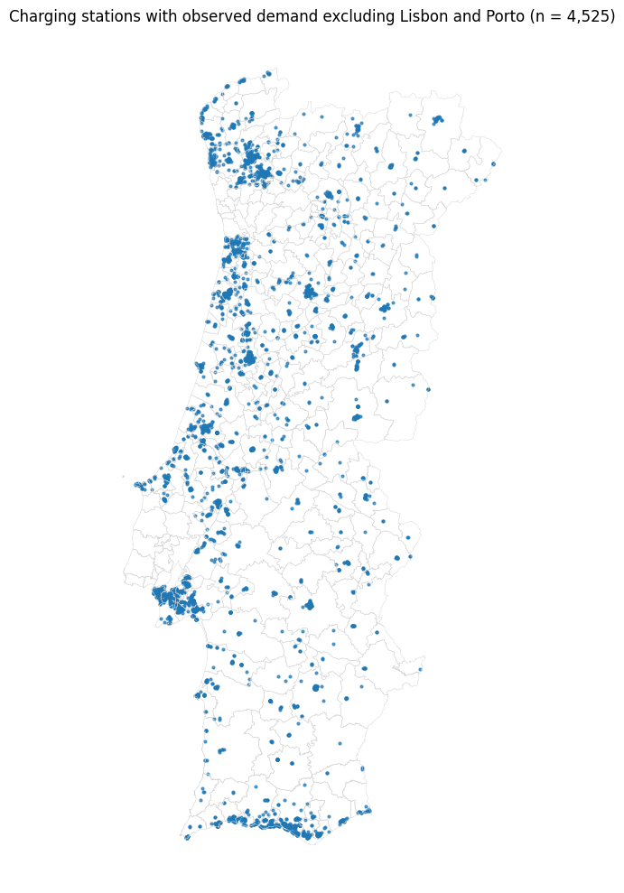

```python
fig, ax = plt.subplots(figsize=(8, 10))

# Mainland municipality/district boundaries
gdf_municipios.boundary.plot(
    ax=ax,
    linewidth=0.3,
    color="lightgrey"
)

# Stations with observed demand after excluding Lisbon and Porto
gdf_sem_lp.plot(
    ax=ax,
    markersize=4,
    alpha=0.7
)

ax.set_title(
    f"Charging stations with observed demand excluding Lisbon and Porto "
    f"(n = {len(gdf_sem_lp):,})"
)

ax.set_axis_off()

plt.tight_layout()

fig.savefig(
    FIG_DIR / "charging_stations_without_lisbon_porto_nb05.png",
    dpi=300,
    bbox_inches="tight"
)

plt.show()
```

```python
# ----------------------------------------------------------------------------------------------------
# Sensitivity analysis of percentile thresholds - recalculate thresholds within the reduced territory
# ----------------------------------------------------------------------------------------------------

percentiles = [0.85, 0.90, 0.95]
priority_sensitivity = []
priority_sets = {}

for q in percentiles:

    pressure_threshold = (
        gdf["sessoes_por_evse_instalado"]
        .quantile(q)
    )

    energy_threshold = (
        gdf["kwh_por_kw_instalado"]
        .quantile(q)
    )

    priority_q = gdf[
        (gdf["lisa_class"] == "High-High")
        &
        (
            gdf["sessoes_por_evse_instalado"]
            >= pressure_threshold
        )
        &
        (
            gdf["kwh_por_kw_instalado"]
            >= energy_threshold
        )
    ].copy()

    priority_sets[q] = set(
        priority_q["id_charging_station"]
    )

    priority_sensitivity.append({
        "Percentile": int(q * 100),
        "Sessions/EVSE threshold":
            pressure_threshold,
        "kWh/kW threshold":
            energy_threshold,
        "Priority stations":
            len(priority_q),
        "Priority stations (%)":
            len(priority_q) / len(gdf) * 100
    })

df_priority_sensitivity = pd.DataFrame(
    priority_sensitivity
)

display(
    df_priority_sensitivity.round(2)
)

"""
for q in percentiles:
    limiar_pressao_sem_lp = (
        gdf_sem_lp[
            "sessoes_por_evse_instalado"
        ]
        .quantile(q)
    )

    limiar_kwh_sem_lp = (
        gdf_sem_lp[
            "kwh_por_kw_instalado"
        ]
        .quantile(q)
    )

    postos_prioritarios_sem_lp = gdf_sem_lp[
        (
            gdf_sem_lp[
                "sessoes_por_evse_instalado"
            ] >= limiar_pressao_sem_lp
        )
        &
        (
            gdf_sem_lp[
                "kwh_por_kw_instalado"
            ] >= limiar_kwh_sem_lp
        )
        &
        (
            gdf_sem_lp["lisa_class"]
            == "High-High"
        )
    ].copy()

    print(
        "Priority stations without Lisbon and Porto: "
        f"{len(postos_prioritarios_sem_lp):,}"
    )
"""
```

|  | Percentile | Sessions/EVSE threshold | kWh/kW threshold | Priority stations | Priority stations (%) |
| --- | --- | --- | --- | --- | --- |
| 0 | 85 | 809.87 | 457.15 | 260 | 2.79 |
| 1 | 90 | 1096.73 | 598.86 | 185 | 1.99 |
| 2 | 95 | 1607.80 | 929.68 | 82 | 0.88 |

[output not shown]

```python
# --------------------------------------------------
# Overlap between percentile scenarios
#   - percentile: 85, 90 e 95
# --------------------------------------------------

overlap_results = []

p90_set = priority_sets[0.90]

for q in percentiles:

    current_set = priority_sets[q]

    overlap = len(
        p90_set.intersection(current_set)
    )

    overlap_results.append({
        "Percentile": int(q * 100),
        "Priority stations": len(current_set),
        "Overlap with P90": overlap,
        "Current scenario in P90 (%)":
            overlap / len(current_set) * 100,
        "P90 retained (%)":
            overlap / len(p90_set) * 100
    })

df_priority_overlap = pd.DataFrame(
    overlap_results
)

display(df_priority_overlap.round(2))
```

|  | Percentile | Priority stations | Overlap with P90 | Current scenario in P90 (%) | P90 retained (%) |
| --- | --- | --- | --- | --- | --- |
| 0 | 85 | 260 | 185 | 71.15 | 100.00 |
| 1 | 90 | 185 | 185 | 100.00 | 100.00 |
| 2 | 95 | 82 | 82 | 100.00 | 44.32 |

```python
sensitivity_cluster_composition = pd.DataFrame({
    "National (%)":
        gdf["cluster"]
        .value_counts(normalize=True)
        .sort_index()
        * 100,

    "Without Lisbon and Porto (%)":
        gdf_sem_lp["cluster"]
        .value_counts(normalize=True)
        .sort_index()
        * 100
}).round(2)

sensitivity_cluster_composition["Difference (pp)"] = (
    sensitivity_cluster_composition[
        "Without Lisbon and Porto (%)"
    ]
    - sensitivity_cluster_composition["National (%)"]
)

display(sensitivity_cluster_composition)

sensitivity_summary = pd.DataFrame({
    "Scenario": [
        "National network",
        "Without Lisbon and Porto"
    ],
    "Stations": [
        len(gdf),
        len(gdf_sem_lp)
    ],
    "Connected KNN (k)": [
        K_NEIGHBORS,
        k_sem_lp
    ],
    "Priority stations": [
        len(postos_prioritarios),
        len(postos_prioritarios_sem_lp)
    ]
})

display(sensitivity_summary)
```

| cluster | National (%) | Without Lisbon and Porto (%) | Difference (pp) |
| --- | --- | --- | --- |
| 0 | 39.06 | 37.46 | -1.60 |
| 1 | 27.91 | 33.70 | 5.79 |
| 2 | 12.84 | 10.92 | -1.92 |
| 3 | 20.20 | 17.92 | -2.28 |

|  | Scenario | Stations | Connected KNN (k) | Priority stations |
| --- | --- | --- | --- | --- |
| 0 | National network | 9309 | 13 | 185 |
| 1 | Without Lisbon and Porto | 4525 | 13 | 63 |

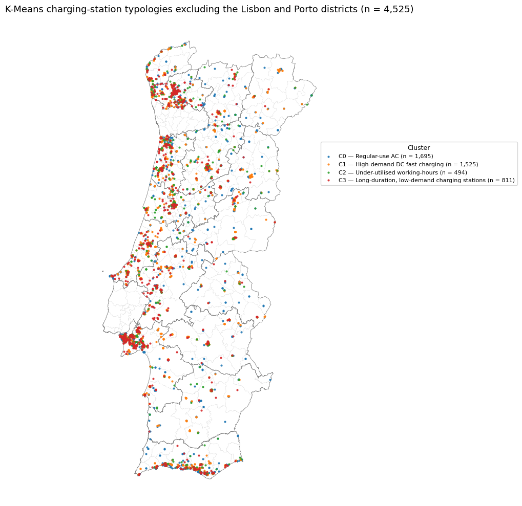

```python
CLUSTER_COLORS = {
    0: "#1f77b4",
    1: "#ff7f0e",
    2: "#2ca02c",
    3: "#d62728"
}

CLUSTER_LABELS = {
    0: "C0 — Regular-use AC",
    1: "C1 — High-demand DC fast charging",
    2: "C2 — Under-utilised working-hours",
    3: "C3 — Long-duration, low-demand charging stations"
}

munic.plot_categories_with_boundaries(
    gdf_points=gdf_sem_lp,
    gdf_mun=gdf_municipios,
    column="cluster",
    colors=CLUSTER_COLORS,
    labels=CLUSTER_LABELS,
    title=(
        "K-Means charging-station typologies "
        "excluding the Lisbon and Porto districts "
        f"(n = {len(gdf_sem_lp):,})"
    ),
    outfile="kmeans_clusters_without_lisbon_porto_nb05.png",
    tight_bbox=True
)
```

## 5.11 Case study: District of Coimbra

The Coimbra analysis applies the national K-Means typologies and the national LISA classification already calculated for the complete network. The clustering model is not retrained for Coimbra. This preserves comparability between the national and local analyses.

```python
# --------------------------------------------------
# Municipal context — District of Coimbra
# --------------------------------------------------

coimbra_municipal_context = read_sql("""
    SELECT
        municipio,
        hab_total_hm,
        n_postos,
        n_evse,
        potencia_total_kw,
        postos_por_10000_hab,
        evse_por_10000_hab,
        kw_por_10000_hab
    FROM v63_contexto_concelho
    WHERE UPPER(distrito) = 'COIMBRA'
    ORDER BY n_postos DESC
""")

display(
    coimbra_municipal_context[
        [
            "municipio",
            "hab_total_hm",
            "n_postos",
            "n_evse",
            "potencia_total_kw",
            "postos_por_10000_hab"
        ]
    ].round(2)
)
```

|  | municipio | hab_total_hm | n_postos | n_evse | potencia_total_kw | postos_por_10000_hab |
| --- | --- | --- | --- | --- | --- | --- |
| 0 | Coimbra | 140816 | 198 | 416.0 | 16931.06 | 14.06 |
| 1 | Figueira da Foz | 58951 | 59 | 133.0 | 9237.70 | 10.01 |
| 2 | Cantanhede | 34212 | 41 | 121.0 | 12506.80 | 11.98 |
| 3 | Condeixa-a-Nova | 16732 | 26 | 72.0 | 6217.10 | 15.54 |
| 4 | Oliveira do Hospital | 19413 | 26 | 68.0 | 3769.62 | 13.39 |
| 5 | Montemor-o-Velho | 24571 | 20 | 43.0 | 2277.90 | 8.14 |
| 6 | Lousã | 17006 | 19 | 35.0 | 886.18 | 11.17 |
| 7 | Tábua | 11160 | 15 | 41.0 | 1174.60 | 13.44 |
| 8 | Soure | 17261 | 12 | 21.0 | 764.30 | 6.95 |
| 9 | Miranda do Corvo | 12002 | 10 | 33.0 | 871.60 | 8.33 |
| 10 | Mira | 12113 | 10 | 23.0 | 1654.00 | 8.26 |
| 11 | Arganil | 11065 | 7 | 18.0 | 649.00 | 6.33 |
| 12 | Penacova | 13113 | 7 | 17.0 | 964.00 | 5.34 |
| 13 | Góis | 3811 | 4 | 12.0 | 264.00 | 10.50 |
| 14 | Penela | 5440 | 3 | 12.0 | 1454.00 | 5.51 |
| 15 | Pampilhosa da Serra | 4082 | 3 | 8.0 | 400.00 | 7.35 |
| 16 | Vila Nova de Poiares | 6803 | 2 | 6.0 | 220.00 | 2.94 |

```python
print(
    "Municipalities:",
    len(coimbra_municipal_context)
)

print(
    "Stations in municipal context:",
    coimbra_municipal_context["n_postos"].sum()
)
```

```
Municipalities: 17
Stations in municipal context: 462
```

```python
gdf_coimbra = gdf[
    gdf["distrito"]
    .str.upper()
    .eq("COIMBRA")
].copy()

print(f"Charging stations in Coimbra: {len(gdf_coimbra):,}")

display(
    gdf_coimbra["cluster"]
    .value_counts()
    .sort_index()
    .rename_axis("Cluster")
    .reset_index(name="Stations")
)

display(
    gdf_coimbra["lisa_class"]
    .value_counts()
    .rename_axis("LISA class")
    .reset_index(name="Stations")
)
```

```
Charging stations in Coimbra: 285
```

|  | Cluster | Stations |
| --- | --- | --- |
| 0 | 0 | 100 |
| 1 | 1 | 95 |
| 2 | 2 | 48 |
| 3 | 3 | 42 |

|  | LISA class | Stations |
| --- | --- | --- |
| 0 | Not significant | 194 |
| 1 | Low-Low | 42 |
| 2 | High-High | 25 |
| 3 | Low-High | 19 |
| 4 | High-Low | 5 |

```python
# --------------------------------------------------
# High-High LISA stations by K-Means typology
# District of Coimbra
# --------------------------------------------------

hh_cluster = (
    gdf_coimbra[
        gdf_coimbra["lisa_class"] == "High-High"
    ]["cluster"]
    .value_counts()
    .sort_index()
)

hh_cluster = (
    hh_cluster
    .rename_axis("Cluster")
    .reset_index(name="High-High stations")
)

hh_cluster["Percentage"] = (
    hh_cluster["High-High stations"]
    / hh_cluster["High-High stations"].sum()
    * 100
).round(1)

display(hh_cluster)

print(
    "Total High-High stations:",
    hh_cluster["High-High stations"].sum()
)
```

|  | Cluster | High-High stations | Percentage |
| --- | --- | --- | --- |
| 0 | 0 | 13 | 52.0 |
| 1 | 1 | 12 | 48.0 |

```
Total High-High stations: 25
```

```python
coimbra_priority = postos_prioritarios[
    postos_prioritarios["distrito"]
    .str.upper()
    .eq("COIMBRA")
].copy()

print(f"Priority stations in Coimbra: {len(coimbra_priority):,}")

# Annonimase id_charging_station
coimbra_priority_annon = anonymise_station_labels(coimbra_priority)

#display(coimbra_priority_annon[["station_label", "n_sessoes", "energia_total_kwh"]])


display(
    coimbra_priority_annon[
        [
            #"id_charging_station",
            "station_label",
            "municipio",
            "cluster",
            "sessoes_por_evse_instalado",
            "kwh_por_kw_instalado",
            "potencia_total_kw"
        ]
    ]
    .sort_values(
        "sessoes_por_evse_instalado",
        ascending=False
    )
)
```

```
Priority stations in Coimbra: 6
```

|  | station_label | municipio | cluster | sessoes_por_evse_instalado | kwh_por_kw_instalado | potencia_total_kw |
| --- | --- | --- | --- | --- | --- | --- |
| 1060 | CS005 | Coimbra | 1 | 2404.5 | 1261.014264 | 110.0 |
| 1059 | CS004 | Coimbra | 1 | 2227.5 | 1181.147745 | 110.0 |
| 1061 | CS006 | Coimbra | 1 | 2138.0 | 1125.612755 | 110.0 |
| 1053 | CS003 | Coimbra | 0 | 1777.0 | 1912.145182 | 11.0 |
| 1051 | CS002 | Coimbra | 0 | 1774.0 | 935.386364 | 22.0 |
| 1047 | CS001 | Coimbra | 0 | 1600.0 | 1301.813792 | 48.0 |

```python
# --------------------------------------------------
# Distribution of K-Means typologies by municipality
# District of Coimbra
# --------------------------------------------------

coimbra_cluster_municipality = pd.crosstab(
    gdf_coimbra["municipio"],
    gdf_coimbra["cluster"]
)

# Garantir que todos os clusters aparecem
coimbra_cluster_municipality = (
    coimbra_cluster_municipality
    .reindex(
        columns=[0, 1, 2, 3],
        fill_value=0
    )
)

# Nomes mais claros
coimbra_cluster_municipality.columns = [
    "C0",
    "C1",
    "C2",
    "C3"
]

# Total por município
coimbra_cluster_municipality["Total"] = (
    coimbra_cluster_municipality[
        ["C0", "C1", "C2", "C3"]
    ].sum(axis=1)
)

# Ordenar pelos municípios com mais postos analisados
coimbra_cluster_municipality = (
    coimbra_cluster_municipality
    .sort_values(
        "Total",
        ascending=False
    )
)

display(
    coimbra_cluster_municipality
    .reset_index()
    .rename(
        columns={
            "municipio": "Municipality"
        }
    )
)
```

|  | Municipality | C0 | C1 | C2 | C3 | Total |
| --- | --- | --- | --- | --- | --- | --- |
| 0 | Coimbra | 51 | 33 | 22 | 21 | 127 |
| 1 | Figueira da Foz | 7 | 17 | 2 | 5 | 31 |
| 2 | Cantanhede | 8 | 12 | 2 | 3 | 25 |
| 3 | Oliveira do Hospital | 5 | 7 | 6 | 2 | 20 |
| 4 | Montemor-o-Velho | 1 | 5 | 4 | 3 | 13 |
| 5 | Condeixa-a-Nova | 2 | 5 | 2 | 3 | 12 |
| 6 | Lousã | 3 | 1 | 4 | 3 | 11 |
| 7 | Tábua | 5 | 2 | 0 | 1 | 8 |
| 8 | Soure | 2 | 2 | 3 | 1 | 8 |
| 9 | Mira | 4 | 3 | 0 | 0 | 7 |
| 10 | Penacova | 1 | 3 | 2 | 0 | 6 |
| 11 | Arganil | 2 | 2 | 1 | 0 | 5 |
| 12 | Miranda do Corvo | 4 | 1 | 0 | 0 | 5 |
| 13 | Penela | 1 | 1 | 0 | 0 | 2 |
| 14 | Pampilhosa da Serra | 1 | 1 | 0 | 0 | 2 |
| 15 | Góis | 2 | 0 | 0 | 0 | 2 |
| 16 | Vila Nova de Poiares | 1 | 0 | 0 | 0 | 1 |

```python
assert (
    coimbra_cluster_municipality["Total"].sum()
    == len(gdf_coimbra)
)

assert (
    coimbra_cluster_municipality[
        ["C0", "C1", "C2", "C3"]
    ].sum().sum()
    == len(gdf_coimbra)
)

print(
    "Municipal cluster table validated:",
    coimbra_cluster_municipality["Total"].sum(),
    "stations"
)
```

```
Municipal cluster table validated: 285 stations
```

```python
coimbra_cluster_municipality_pct = (
    coimbra_cluster_municipality[
        ["C0", "C1", "C2", "C3"]
    ]
    .div(
        coimbra_cluster_municipality["Total"],
        axis=0
    )
    .mul(100)
    .round(1)
)

display(
    coimbra_cluster_municipality_pct
    .reset_index()
    .rename(
        columns={
            "municipio": "Municipality"
        }
    )
)
```

|  | Municipality | C0 | C1 | C2 | C3 |
| --- | --- | --- | --- | --- | --- |
| 0 | Coimbra | 40.2 | 26.0 | 17.3 | 16.5 |
| 1 | Figueira da Foz | 22.6 | 54.8 | 6.5 | 16.1 |
| 2 | Cantanhede | 32.0 | 48.0 | 8.0 | 12.0 |
| 3 | Oliveira do Hospital | 25.0 | 35.0 | 30.0 | 10.0 |
| 4 | Montemor-o-Velho | 7.7 | 38.5 | 30.8 | 23.1 |
| 5 | Condeixa-a-Nova | 16.7 | 41.7 | 16.7 | 25.0 |
| 6 | Lousã | 27.3 | 9.1 | 36.4 | 27.3 |
| 7 | Tábua | 62.5 | 25.0 | 0.0 | 12.5 |
| 8 | Soure | 25.0 | 25.0 | 37.5 | 12.5 |
| 9 | Mira | 57.1 | 42.9 | 0.0 | 0.0 |
| 10 | Penacova | 16.7 | 50.0 | 33.3 | 0.0 |
| 11 | Arganil | 40.0 | 40.0 | 20.0 | 0.0 |
| 12 | Miranda do Corvo | 80.0 | 20.0 | 0.0 | 0.0 |
| 13 | Penela | 50.0 | 50.0 | 0.0 | 0.0 |
| 14 | Pampilhosa da Serra | 50.0 | 50.0 | 0.0 | 0.0 |
| 15 | Góis | 100.0 | 0.0 | 0.0 | 0.0 |
| 16 | Vila Nova de Poiares | 100.0 | 0.0 | 0.0 | 0.0 |

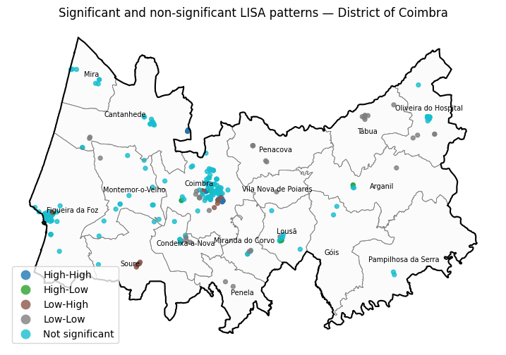

```python
gdf_municipios_coimbra = gdf_municipios[
    gdf_municipios["distrito"]
    .str.upper()
    .eq("COIMBRA")
].copy()

fig, ax = munic.plot_categorias_distrito(
    gdf_postos=gdf_coimbra,
    gdf_municipios=gdf_municipios_coimbra,
    distrito="Coimbra",
    coluna="lisa_class",
    titulo="Significant and non-significant LISA patterns — District of Coimbra",
    labels=True,
    markersize=18,
    alpha=0.8
)

fig.savefig(
    FIG_DIR / "lisa_patterns_coimbra_nb05.png",
    dpi=300,
    bbox_inches="tight"
)

plt.show()
```

```python
# -----------------------------------------------------------
# High-High stations in Coimbra district, by municipality
# -----------------------------------------------------------

hh_coimbra_municipality = (
    gdf_coimbra[
        gdf_coimbra["lisa_class"] == "High-High"
    ]
    ["municipio"]
    .value_counts()
    .rename_axis("Municipality")
    .reset_index(name="High-High stations")
)

display(hh_coimbra_municipality)
```

|  | Municipality | High-High stations |
| --- | --- | --- |
| 0 | Coimbra | 22 |
| 1 | Cantanhede | 3 |

```python
# -------------------------------------------------
# Priority stations by municipality
# -------------------------------------------------

priority_coimbra_municipality = (
    coimbra_priority["municipio"]
    .value_counts()
    .rename_axis("Municipality")
    .reset_index(name="Priority stations")
)

display(priority_coimbra_municipality)
```

|  | Municipality | Priority stations |
| --- | --- | --- |
| 0 | Coimbra | 6 |

```python
cantanhede_hh = gdf_coimbra[
    (gdf_coimbra["municipio"] == "Cantanhede")
    &
    (gdf_coimbra["lisa_class"] == "High-High")
].copy()

cantanhede_hh["above_p90_pressure"] = (
    cantanhede_hh["sessoes_por_evse_instalado"]
    >= limiar_pressao
)

cantanhede_hh["above_p90_energy"] = (
    cantanhede_hh["kwh_por_kw_instalado"]
    >= limiar_kwh
)

cantanhede_hh["would_be_priority"] = (
    cantanhede_hh["above_p90_pressure"]
    &
    cantanhede_hh["above_p90_energy"]
)
cantanhede_hh = anonymise_station_labels(cantanhede_hh)

display(
    cantanhede_hh[
        [
            "station_label",
            "cluster",
            "sessoes_por_evse_instalado",
            "kwh_por_kw_instalado",
            "above_p90_pressure",
            "above_p90_energy",
            "would_be_priority"
        ]
    ].round(2)
)
```

|  | station_label | cluster | sessoes_por_evse_instalado | kwh_por_kw_instalado | above_p90_pressure | above_p90_energy | would_be_priority |
| --- | --- | --- | --- | --- | --- | --- | --- |
| 1256 | CS001 | 1 | 444.75 | 44.85 | False | False | False |
| 1257 | CS002 | 1 | 527.75 | 56.85 | False | False | False |
| 1258 | CS003 | 1 | 468.00 | 48.52 | False | False | False |

```python
coimbra_priority_table = (
    anonymise_station_labels(coimbra_priority)
    [
        [
            "station_label",
            "municipio",
            "cluster",
            "lisa_class",
            "sessoes_por_evse_instalado",
            "kwh_por_kw_instalado",
            "n_evse_instalados",
            "potencia_total_kw",
            "road_number",
            "dist_via_m"
        ]
    ]
    .sort_values(
        "sessoes_por_evse_instalado",
        ascending=False
    )
)

display(coimbra_priority_table.round(2))
```

|  | station_label | municipio | cluster | lisa_class | sessoes_por_evse_instalado | kwh_por_kw_instalado | n_evse_instalados | potencia_total_kw | road_number | dist_via_m |
| --- | --- | --- | --- | --- | --- | --- | --- | --- | --- | --- |
| 1060 | CS005 | Coimbra | 1 | High-High | 2404.5 | 1261.01 | 2 | 110.0 | IC3 | 526.87 |
| 1059 | CS004 | Coimbra | 1 | High-High | 2227.5 | 1181.15 | 2 | 110.0 | IC3 | 526.87 |
| 1061 | CS006 | Coimbra | 1 | High-High | 2138.0 | 1125.61 | 2 | 110.0 | IC3 | 526.87 |
| 1053 | CS003 | Coimbra | 0 | High-High | 1777.0 | 1912.15 | 1 | 11.0 | IC2 | 178.40 |
| 1051 | CS002 | Coimbra | 0 | High-High | 1774.0 | 935.39 | 1 | 22.0 | IC2 | 178.40 |
| 1047 | CS001 | Coimbra | 0 | High-High | 1600.0 | 1301.81 | 2 | 48.0 | IC2 | 178.40 |

```python
municipality_lisa = (
    pd.crosstab(
        gdf_coimbra["municipio"],
        gdf_coimbra["lisa_class"]
    )
    .reindex(
        columns=[
            "High-High",
            "High-Low",
            "Low-High",
            "Low-Low",
            "Not significant"
        ],
        fill_value=0
    )
)

municipality_lisa["Total"] = municipality_lisa.sum(axis=1)

municipality_lisa = (
    municipality_lisa
    .sort_values(
        "Total",
        ascending=False
    )
)

display(
    municipality_lisa
    .reset_index()
    .rename(
        columns={
            "municipio":"Municipality"
        }
    )
)
```

| lisa_class | Municipality | High-High | High-Low | Low-High | Low-Low | Not significant | Total |
| --- | --- | --- | --- | --- | --- | --- | --- |
| 0 | Coimbra | 22 | 2 | 11 | 8 | 84 | 127 |
| 1 | Figueira da Foz | 0 | 0 | 1 | 0 | 30 | 31 |
| 2 | Cantanhede | 3 | 0 | 1 | 2 | 19 | 25 |
| 3 | Oliveira do Hospital | 0 | 0 | 0 | 4 | 16 | 20 |
| 4 | Montemor-o-Velho | 0 | 0 | 0 | 1 | 12 | 13 |
| 5 | Condeixa-a-Nova | 0 | 1 | 0 | 6 | 5 | 12 |
| 6 | Lousã | 0 | 1 | 0 | 1 | 9 | 11 |
| 7 | Tábua | 0 | 0 | 0 | 8 | 0 | 8 |
| 8 | Soure | 0 | 0 | 6 | 0 | 2 | 8 |
| 9 | Mira | 0 | 0 | 0 | 0 | 7 | 7 |
| 10 | Penacova | 0 | 0 | 0 | 6 | 0 | 6 |
| 11 | Arganil | 0 | 1 | 0 | 1 | 3 | 5 |
| 12 | Miranda do Corvo | 0 | 0 | 0 | 2 | 3 | 5 |
| 13 | Penela | 0 | 0 | 0 | 2 | 0 | 2 |
| 14 | Pampilhosa da Serra | 0 | 0 | 0 | 0 | 2 | 2 |
| 15 | Góis | 0 | 0 | 0 | 0 | 2 | 2 |
| 16 | Vila Nova de Poiares | 0 | 0 | 0 | 1 | 0 | 1 |

```python
CLUSTER_LABELS = {
    0: "C0 — Regular-use AC",
    1: "C1 — High-demand DC fast charging",
    2: "C2 — Under-utilised working-hours",
    3: "C3 — Long-duration, low-demand charging stations"
}

hh_cluster = (
    gdf_coimbra[
        gdf_coimbra["lisa_class"] == "High-High"
    ]["cluster"]
    .value_counts()
    .sort_index()
)

hh_cluster = (
    hh_cluster
    .rename_axis("Cluster")
    .reset_index(name="High-High stations")
)

hh_cluster["Operational typology"] = (
    hh_cluster["Cluster"].map(CLUSTER_LABELS)
)

hh_cluster["Percentage"] = (
    hh_cluster["High-High stations"]
    / hh_cluster["High-High stations"].sum()
    * 100
).round(1)

display(
    hh_cluster[
        [
            "Operational typology",
            "High-High stations",
            "Percentage"
        ]
    ]
)
```

|  | Operational typology | High-High stations | Percentage |
| --- | --- | --- | --- |
| 0 | C0 — Regular-use AC | 13 | 52.0 |
| 1 | C1 — High-demand DC fast charging | 12 | 48.0 |

```python
priority_station_summary = (
    coimbra_priority[
        [
            "municipio",
            "cluster",
            "sessoes_por_evse_instalado",
            "kwh_por_kw_instalado",
            "n_evse_instalados",
            "potencia_total_kw",
            "road_number"
        ]
    ]
    .sort_values(
        "sessoes_por_evse_instalado",
        ascending=False
    )
)

display(priority_station_summary.round(2))
```

|  | municipio | cluster | sessoes_por_evse_instalado | kwh_por_kw_instalado | n_evse_instalados | potencia_total_kw | road_number |
| --- | --- | --- | --- | --- | --- | --- | --- |
| 1060 | Coimbra | 1 | 2404.5 | 1261.01 | 2 | 110.0 | IC3 |
| 1059 | Coimbra | 1 | 2227.5 | 1181.15 | 2 | 110.0 | IC3 |
| 1061 | Coimbra | 1 | 2138.0 | 1125.61 | 2 | 110.0 | IC3 |
| 1053 | Coimbra | 0 | 1777.0 | 1912.15 | 1 | 11.0 | IC2 |
| 1051 | Coimbra | 0 | 1774.0 | 935.39 | 1 | 22.0 | IC2 |
| 1047 | Coimbra | 0 | 1600.0 | 1301.81 | 2 | 48.0 | IC2 |

```python
priority_station_summary = (
    anonymise_station_labels(coimbra_priority)
    [
        [
            "station_label",
            "municipio",
            "cluster",
            "sessoes_por_evse_instalado",
            "kwh_por_kw_instalado",
            "n_evse_instalados",
            "potencia_total_kw",
            "road_number"
        ]
    ]
    .sort_values(
        "sessoes_por_evse_instalado",
        ascending=False
    )
)

display(priority_station_summary.round(2))
```

|  | station_label | municipio | cluster | sessoes_por_evse_instalado | kwh_por_kw_instalado | n_evse_instalados | potencia_total_kw | road_number |
| --- | --- | --- | --- | --- | --- | --- | --- | --- |
| 1060 | CS005 | Coimbra | 1 | 2404.5 | 1261.01 | 2 | 110.0 | IC3 |
| 1059 | CS004 | Coimbra | 1 | 2227.5 | 1181.15 | 2 | 110.0 | IC3 |
| 1061 | CS006 | Coimbra | 1 | 2138.0 | 1125.61 | 2 | 110.0 | IC3 |
| 1053 | CS003 | Coimbra | 0 | 1777.0 | 1912.15 | 1 | 11.0 | IC2 |
| 1051 | CS002 | Coimbra | 0 | 1774.0 | 935.39 | 1 | 22.0 | IC2 |
| 1047 | CS001 | Coimbra | 0 | 1600.0 | 1301.81 | 2 | 48.0 | IC2 |

```python
priority_municipality = (
    coimbra_priority["municipio"]
    .value_counts()
    .rename_axis("Municipality")
    .reset_index(name="Priority stations")
)

priority_municipality["Share (%)"] = (
    priority_municipality["Priority stations"]
    / priority_municipality["Priority stations"].sum()
    *100
).round(1)

display(priority_municipality)
```

|  | Municipality | Priority stations | Share (%) |
| --- | --- | --- | --- |
| 0 | Coimbra | 6 | 100.0 |

## 5.13 Export of results

```python
rq3_context = gdf[
    [
        "id_charging_station",
        "distrito",
        "municipio",
        "dtmn",
        "cluster",
        "lisa_quadrant",
        "lisa_pvalue",
        "lisa_significant",
        "lisa_class",
        "sessoes_mes_ativo",
        "sessoes_por_evse_instalado",
        "kwh_por_kw_instalado"
    ]
].copy()

rq3_context.to_csv(
    "../outputs/rq3_context.csv",
    index=False
)

postos_prioritarios[
    [
        "id_charging_station",
        "distrito",
        "municipio",
        "dtmn",
        "cluster",
        "lisa_class",
        "sessoes_por_evse_instalado",
        "kwh_por_kw_instalado",
        "potencia_total_kw"
    ]
].to_csv(
    "../outputs/rq3_priority_stations.csv",
    index=False
)

gdf_sem_lp[
    [
        "id_charging_station",
        "distrito",
        "municipio",
        "cluster",
        "lisa_class"
    ]
].to_csv(
    "../outputs/rq3_without_lisbon_porto.csv",
    index=False
)

print("RQ3 outputs exported successfully.")
```

```
RQ3 outputs exported successfully.
```